# Ismet Tez

Ismet Ozer

26 07 2021

```r
knitr::opts_chunk$set(message=FALSE, warning=FALSE, comment = NA)
knitr::opts_chunk$set(fig.width=12, fig.height=8)

library(flextable)
library(report)
library(reactable)
library(skimr)
library(dlookr)
library(performance)
library(see)
library(car)
library(dplyr)
library(tidyr)
library(pastecs)
library(broom)
library(ggplot2)
library(ggfortify)
library(plotly)
library(ggpubr)
library(GGally)
library(performance)
library(modelbased)
library(DataExplorer)
```

# Loading and handling data

```r
tez <- read.csv("../data/finalData.csv", sep = ";")

tez <- tez %>% dplyr::rename(IGT = NET,
                             IGT_1 = NET1,
                             IGT_2 = NET2,
                             IGT_3 = NET3,
                             IGT_4 = NET4,
                             IGT_5 = NET5,
                             BART = adjustedaveragepumpcount,
                             BART_1 = adjustedaveragepumpcount_10,
                             BART_2 = adjustedaveragepumpcount_20,
                             BART_3 = adjustedaveragepumpcount_30)

# Barratt Impulsiveness Scale
## Barratt reversing items
bar_rev_cols <- c("barratt_1", "barratt_5","barratt_6","barratt_11","barratt_15")

tez[, bar_rev_cols] <- 5 - tez[, bar_rev_cols]

tez[, bar_rev_cols] <- lapply(tez[, bar_rev_cols], as.integer)

## Total and subscales of Barratt scores
tez <- tez %>% mutate(barratt_total = rowSums(select(., c(barratt_1:barratt_15))),
                      barratt_atten = rowSums(select(., c(barratt_1, barratt_5, barratt_6, barratt_11, barratt_15))),
                      barratt_motor = rowSums(select(., c(barratt_4, barratt_10, barratt_12, barratt_13, barratt_14))),
                      barratt_atten = rowSums(select(., c(barratt_2, barratt_3, barratt_7, barratt_8, barratt_9))))

# Sensation Seeking Scale
## Total SSS
tez <- tez %>% mutate(sss_total = rowSums(select(., c(sss_1:sss_8))))

# Ok-Religious Attitudes
## Ok-Religious Attitudes reversing items
ok_rev_cols <- c("ok_religious_attitudes_1", "ok_religious_attitudes_2")

tez[, ok_rev_cols] <- 6 - tez[, ok_rev_cols]

tez[, ok_rev_cols] <- lapply(tez[, ok_rev_cols], as.integer)

## Total and subscales of Ok-Religious Attitudes Scale
tez <- tez %>% mutate(okRelig_total = rowSums(select(., c(ok_religious_attitudes_1:ok_religious_attitudes_8))),
                      okRelig_cog = rowSums(select(., c(ok_religious_attitudes_1,ok_religious_attitudes_2))),
                      okRelig_feel = rowSums(select(., c(ok_religious_attitudes_3,ok_religious_attitudes_4))),
                      okRelig_behav = rowSums(select(., c(ok_religious_attitudes_5,ok_religious_attitudes_6))),
                      okRelig_rel2god = rowSums(select(., c(ok_religious_attitudes_7,ok_religious_attitudes_8))))

# Intuitive Religion Scale
## reversing items
int_rev_cols <- c("intuitive_religion_3", "intuitive_religion_4", "intuitive_religion_5")

tez[, int_rev_cols] <- 6 - tez[, int_rev_cols]

tez[, int_rev_cols] <- lapply(tez[, int_rev_cols], as.integer)

## Total Intuitive Religion Scale score
tez <- tez %>% mutate(intuRelig_total = rowSums(select(., c(intuitive_religion_1:intuitive_religion_5))))

#Removing variables
tez <- tez %>% select(-barratt_1:-barratt_15,
                      -sss_1:-sss_8,
                      -religion,
                      -ok_religious_attitudes_1: -ok_religious_attitudes_8,
                      -intuitive_religion_1:-intuitive_religion_5)

tez$education <- ifelse(tez$bau_student == 1, 2, tez$education)

# Correcting data types
tez$bau_student <- factor(tez$bau_student, labels = c("Student", "Not Student"))
tez$group <- factor(tez$group, labels = c("Punishing", "Non-punishing", "Control"))
tez$sex <- factor(tez$sex, labels = c("Female", "Male"))
tez$education <- factor(tez$education, labels = c("Graduate", "Undergraduate", "Associate", "Highschool"))
tez$dominant_hand <- factor(tez$dominant_hand, labels = c("Left", "Right"))
tez$place <- factor(tez$place, levels = c(1:5), labels = c("Metropolis", "City",    "Town", "Borough", "Village"))
tez$income <- factor(tez$income, levels = c(1:5), labels = c("Very well", "Good", "Not bad", "Bad", "Very bad"))
tez$IGT_awareness_2 <- factor(tez$IGT_awareness_2, labels = c("Yes", "No"))
tez$IGT_awareness_3_A <- factor(tez$IGT_awareness_3_A, labels = c("Win", "Lose"))
tez$IGT_awareness_4_B <- factor(tez$IGT_awareness_4_B, labels = c("Win", "Lose"))
tez$IGT_awareness_5_C <- factor(tez$IGT_awareness_5_C, labels = c("Win", "Lose"))
tez$IGT_awareness_6_D <- factor(tez$IGT_awareness_6_D, labels = c("Win", "Lose"))
tez$IGT_awareness_7 <- factor(tez$IGT_awareness_7, labels = c("1. Deck", "2. Deck", "3. Deck", "4. Deck"))

tez$barratt_code <- if (tez$barratt_total <= mean(tez$barratt_total)- sd(tez$barratt_total)) {
  tez$barratt_code = 1
} else if (tez$barratt_total >= mean(tez$barratt_total) + sd(tez$barratt_total)) {
  tez$barratt_code = 3
} else {
  tez$barratt_code = 2
}

# Group coding for barratt_total
## 1 for values < mean - sd, 2 for mean - sd < values < mean + sd, 3 for values > mean + sd
tez$barratt_code <- ifelse(
  (tez$barratt_total <= mean(tez$barratt_total) - sd(tez$barratt_total)), 1,
  ifelse(
    (tez$barratt_total >= mean(tez$barratt_total) + sd(tez$barratt_total)), 3, 2
    )
  )

tez$barratt_code <- factor(tez$barratt_code,
                           levels = c(1:3),
                           labels = c("Low", "Medium", "High"),
                           ordered = T)

# Group coding for sss_total
## 1 for values < mean - sd, 2 for mean - sd < values < mean + sd, 3 for values > mean + sd
tez$sss_code <- ifelse(
  (tez$sss_total <= mean(tez$sss_total) - sd(tez$sss_total)), 1,
  ifelse(
    (tez$sss_total >= mean(tez$sss_total) + sd(tez$sss_total)), 3, 2
    )
  )

tez$sss_code <- factor(tez$sss_code,
                           levels = c(1:3),
                           labels = c("Low", "Medium", "High"),
                           ordered = T)

# Group coding for okRelig_total
## 1 for values < mean - sd, 2 for mean - sd < values < mean + sd, 3 for values > mean + sd
tez$okRelig_code <- ifelse(
  (tez$okRelig_total <= mean(tez$okRelig_total) - sd(tez$okRelig_total)), 1,
  ifelse(
    (tez$okRelig_total >= mean(tez$okRelig_total) + sd(tez$okRelig_total)), 3, 2
    )
  )

tez$okRelig_code <- factor(tez$okRelig_code,
                           levels = c(1:3),
                           labels = c("Low", "Medium", "High"),
                           ordered = T)


# Group coding for intuRelig_total
## Replacing NA values with group means

tez <- tez %>%
  dplyr::group_by(group) %>%
  mutate_at(vars(intuRelig_total),  funs(replace(., which(is.na(.)),
                                round(mean(., na.rm=TRUE)))))

## 1 for values < mean - sd, 2 for mean - sd < values < mean + sd, 3 for values > mean + sd
tez$intuRelig_code <- ifelse(
  (tez$intuRelig_total <= mean(tez$intuRelig_total) - sd(tez$intuRelig_total)), 1,
  ifelse(
    (tez$intuRelig_total >= mean(tez$intuRelig_total) + sd(tez$intuRelig_total)), 3, 2
    )
  )

tez$intuRelig_code <- factor(tez$intuRelig_code,
                             levels = c(1:3),
                             labels = c("Low", "Medium", "High"),
                             ordered = T)


# Group coding for BART awareness
## 1 for values < 16, 2 for 15 < values < 31, 3 for values > 30
tez$BART_awareness_code <- ifelse(
  (tez$BART_awareness_1 <= 16), 1,
  ifelse(
    (tez$BART_awareness_1 >= 16 & tez$BART_awareness_1 <= 31), 2, 3
    )
)

tez$BART_awareness_code <- factor(tez$BART_awareness_1,
                             levels = c(1:3),
                             labels = c("0-15", "15-30", ">30"),
                             ordered = T)


# Coding IGT Knowledge
# tez$IGT_knowledge <- ifelse(
#   (tez$IGT_awareness_5_C == "Lose" & tez$IGT_awareness_6_D == "Lose") &
#      (tez$IGT_awareness_7 == "1. Deck" | tez$IGT_awareness_7 ==  "2. Deck"), "Level 0",
#   ifelse(
#     (tez$IGT_awareness_5_C == "Lose" | tez$IGT_awareness_6_D == "Lose") &
#        (tez$IGT_awareness_7 == "3. Deck" | tez$IGT_awareness_7 ==  "4. Deck"), "Level 1",
#     ifelse(
#       (tez$IGT_awareness_5_C == "Win" | tez$IGT_awareness_6_D == "Win") &
#         (tez$IGT_awareness_7 == "3. Deck" | tez$IGT_awareness_7 ==  "4. Deck"), "Level 2", NA
#     )
#   )
# )


# Inserting ID numbers

tez <- tez %>% ungroup() %>% dplyr::mutate(id = row_number())
tez <- tez %>% dplyr::relocate(id, .before = bau_student)

tez <- tez %>% dplyr::group_by(group) %>%
  dplyr::mutate(id_in_group = row_number())
tez <- tez %>% dplyr::relocate(id_in_group, .before = bau_student)

# Removing unrelated columns

tez <- tez %>%
  select(-totalearnings:-adjustedtotalpumpcount_30,
         -currenttotal:-countDisAdvantage_total,
         -countAdvantage1,-countAdvantage2, -countAdvantage3,
         -countAdvantage4,-countAdvantage5,-countDisAdvantage1,
         -countDisAdvantage2, -countDisAdvantage3,
         -countDisAdvantage4, -countDisAdvantage5, -countDisAdvantage_total, -BART_awareness_code,
         -IGT_awareness_1:-IGT_awareness_7,
         -deckOrderGroup, -email
         )


# tez <- tez %>%
#   select(-IGT_awareness_1:-IGT_awareness_7)

# tez$IGT_awareness_2 <- ifelse(is.na(tez$IGT_awareness_2), 2, tez$IGT_awareness_2)
#
# tez$IGT_knowledge <- if (tez$deckOrderGroup == 1) {
#   ifelse(
#     (tez$IGT_awareness_5_C == "Lose" & tez$IGT_awareness_6_D == "Lose") &
#       (tez$IGT_awareness_7 == "1. Deck" | tez$IGT_awareness_7 ==  "2. Deck"), "Level 0",
#     ifelse(
#       (tez$IGT_awareness_5_C == "Lose" | tez$IGT_awareness_6_D == "Lose") &
#         (tez$IGT_awareness_7 == "3. Deck" | tez$IGT_awareness_7 ==  "4. Deck"), "Level 1",
#       ifelse(
#         (tez$IGT_awareness_5_C == "Win" | tez$IGT_awareness_6_D == "Win") &
#           (tez$IGT_awareness_7 == "3. Deck" | tez$IGT_awareness_7 ==  "4. Deck"), "Level 2", NA
#         )
#       )
#   )
#
# } else if (tez$deckOrderGroup == 2) {
#     ifelse(
#     (tez$IGT_awareness_3_A == "Lose" & tez$IGT_awareness_5_C == "Lose") &
#       (tez$IGT_awareness_7 == "2. Deck" | tez$IGT_awareness_7 ==  "3. Deck"), "Level 0",
#     ifelse(
#       (tez$IGT_awareness_3_A == "Lose" & tez$IGT_awareness_5_C == "Lose") &
#         (tez$IGT_awareness_7 == "1. Deck" | tez$IGT_awareness_7 ==  "4. Deck"), "Level 1",
#       ifelse(
#         (tez$IGT_awareness_3_A == "Win" | tez$IGT_awareness_5_C == "Win") &
#           (tez$IGT_awareness_7 == "1. Deck" | tez$IGT_awareness_7 ==  "4. Deck"), "Level 2", NA
#         )
#       )
#   )
#
# } else if (tez$deckOrderGroup == 3) {
#   ifelse(
#     (tez$IGT_awareness_3_A == "Lose" & tez$IGT_awareness_4_B == "Lose") &
#       (tez$IGT_awareness_7 == "3. Deck" | tez$IGT_awareness_7 ==  "4. Deck"), "Level 0",
#     ifelse(
#       (tez$IGT_awareness_3_A == "Lose" | tez$IGT_awareness_4_B == "Lose") &
#         (tez$IGT_awareness_7 == "1. Deck" | tez$IGT_awareness_7 ==  "2. Deck"), "Level 1",
#       ifelse(
#         (tez$IGT_awareness_3_A == "Win" | tez$IGT_awareness_4_B == "Win") &
#           (tez$IGT_awareness_7 == "1. Deck" | tez$IGT_awareness_7 ==  "2. Deck"), "Level 2", NA
#         )
#       )
#   )
# } else if (tez$deckOrderGroup == 4) {
#   ifelse(
#     (tez$IGT_awareness_4_B == "Lose" & tez$IGT_awareness_5_C == "Lose") &
#       (tez$IGT_awareness_7 == "1. Deck" | tez$IGT_awareness_7 ==  "4. Deck"), "Level 0",
#     ifelse(
#       (tez$IGT_awareness_4_B == "Lose" | tez$IGT_awareness_5_C == "Lose") &
#         (tez$IGT_awareness_7 == "2. Deck" | tez$IGT_awareness_7 ==  "3. Deck"), "Level 1",
#       ifelse(
#         (tez$IGT_awareness_4_B == "Win" | tez$IGT_awareness_5_C == "Win") &
#           (tez$IGT_awareness_7 == "2. Deck" | tez$IGT_awareness_7 ==  "3. Deck"), "Level 2", NA
#         )
#       )
#   )
# }
```

# Data Exploration

Variables that end with "_code" are arbitrarily coded as:

- Low is smaller than mean - sd
- High is bigger than mean + sd
- Medium is between low and high

## Introducing Data

### All Data

#### Factor Variables

```r
tez %>% ungroup() %>%
  skim() %>% yank("factor") %>%
  flextable() %>% colformat_double(digits = 2)
```

| skim_variable | n_missing | complete_rate | ordered | n_unique | top_counts |
| --- | --- | --- | --- | --- | --- |
| bau_student | 0 | 1.00 | FALSE | 2 | Not: 27, Stu: 18 |
| group | 0 | 1.00 | FALSE | 3 | Pun: 15, Non: 15, Con: 15 |
| sex | 1 | 0.98 | FALSE | 2 | Fem: 25, Mal: 19 |
| education | 0 | 1.00 | FALSE | 4 | Und: 37, Hig: 5, Ass: 2, Gra: 1 |
| dominant_hand | 0 | 1.00 | FALSE | 2 | Rig: 37, Lef: 8 |
| place | 0 | 1.00 | FALSE | 3 | Met: 29, Cit: 15, Tow: 1, Bor: 0 |
| income | 0 | 1.00 | FALSE | 4 | Goo: 20, Not: 18, Ver: 5, Bad: 2 |
| barratt_code | 0 | 1.00 | TRUE | 3 | Med: 28, Low: 9, Hig: 8 |
| sss_code | 0 | 1.00 | TRUE | 3 | Med: 31, Low: 7, Hig: 7 |
| okRelig_code | 0 | 1.00 | TRUE | 3 | Med: 30, Hig: 9, Low: 6 |
| intuRelig_code | 0 | 1.00 | TRUE | 3 | Med: 25, Hig: 11, Low: 9 |

#### Numeric Variables

```r
tez %>% ungroup() %>%
  skim() %>% yank("numeric") %>%
  flextable() %>% colformat_double(digits = 2)
```

| skim_variable | n_missing | complete_rate | mean | sd | p0 | p25 | p50 | p75 | p100 | hist |
| --- | --- | --- | --- | --- | --- | --- | --- | --- | --- | --- |
| id | 0 | 1.00 | 23.00 | 13.13 | 1.00 | 12.00 | 23.00 | 34.00 | 45.00 | ▇▇▇▇▇ |
| id_in_group | 0 | 1.00 | 8.00 | 4.37 | 1.00 | 4.00 | 8.00 | 12.00 | 15.00 | ▇▇▇▇▇ |
| age | 0 | 1.00 | 23.71 | 2.98 | 18.00 | 22.00 | 23.00 | 26.00 | 31.00 | ▂▇▃▃▂ |
| religion_rating | 0 | 1.00 | 4.31 | 1.47 | 1.00 | 3.00 | 4.00 | 5.00 | 7.00 | ▃▅▆▇▆ |
| god_exists_rating | 0 | 1.00 | 88.67 | 15.46 | 45.00 | 85.00 | 95.00 | 100.00 | 100.00 | ▁▁▁▂▇ |
| BART_awareness_1 | 0 | 1.00 | 25.64 | 22.34 | 5.00 | 15.00 | 20.00 | 30.00 | 150.00 | ▇▁▁▁▁ |
| BART | 0 | 1.00 | 23.18 | 11.39 | 3.17 | 19.48 | 23.32 | 26.92 | 58.40 | ▅▇▅▂▁ |
| BART_1 | 0 | 1.00 | 18.38 | 9.29 | 3.30 | 12.57 | 18.38 | 24.38 | 41.33 | ▆▇▇▃▂ |
| BART_2 | 0 | 1.00 | 24.29 | 13.83 | 2.00 | 16.50 | 23.43 | 25.00 | 59.67 | ▃▇▁▁▁ |
| BART_3 | 0 | 1.00 | 28.48 | 17.29 | 1.60 | 22.56 | 26.67 | 34.00 | 90.00 | ▃▇▂▁▁ |
| IGT | 0 | 1.00 | 6.98 | 26.91 | -66.00 | -12.00 | 12.00 | 22.00 | 72.00 | ▂▅▇▇▂ |
| IGT_1 | 0 | 1.00 | -1.24 | 5.66 | -14.00 | -4.00 | -2.00 | 2.00 | 14.00 | ▁▃▇▁▁ |
| IGT_2 | 0 | 1.00 | -0.53 | 8.06 | -20.00 | -2.00 | 2.00 | 4.00 | 14.00 | ▂▂▆▇▃ |
| IGT_3 | 0 | 1.00 | -0.36 | 8.65 | -16.00 | -8.00 | 0.00 | 4.00 | 20.00 | ▅▅▇▃▂ |
| IGT_4 | 0 | 1.00 | 3.56 | 9.03 | -20.00 | -2.00 | 4.00 | 8.00 | 20.00 | ▂▃▇▇▃ |
| IGT_5 | 0 | 1.00 | 5.56 | 7.94 | -12.00 | 0.00 | 6.00 | 8.00 | 20.00 | ▂▆▇▇▅ |
| barratt_total | 0 | 1.00 | 31.89 | 5.95 | 19.00 | 27.00 | 34.00 | 37.00 | 41.00 | ▃▅▅▇▇ |
| barratt_atten | 0 | 1.00 | 10.82 | 2.55 | 6.00 | 9.00 | 11.00 | 12.00 | 16.00 | ▃▂▇▃▁ |
| barratt_motor | 0 | 1.00 | 11.24 | 2.23 | 7.00 | 9.00 | 11.00 | 13.00 | 16.00 | ▂▆▇▅▂ |
| sss_total | 0 | 1.00 | 23.73 | 6.26 | 11.00 | 20.00 | 23.00 | 26.00 | 38.00 | ▂▅▇▁▂ |
| okRelig_total | 0 | 1.00 | 25.69 | 5.88 | 14.00 | 22.00 | 25.00 | 28.00 | 39.00 | ▃▇▇▂▂ |
| okRelig_cog | 0 | 1.00 | 7.51 | 1.77 | 3.00 | 7.00 | 7.00 | 9.00 | 10.00 | ▁▂▇▅▆ |
| okRelig_feel | 0 | 1.00 | 5.13 | 1.91 | 2.00 | 4.00 | 5.00 | 6.00 | 10.00 | ▆▇▅▆▁ |
| okRelig_behav | 0 | 1.00 | 5.84 | 2.01 | 2.00 | 5.00 | 6.00 | 7.00 | 10.00 | ▅▇▆▇▂ |
| okRelig_rel2god | 0 | 1.00 | 7.20 | 1.94 | 3.00 | 6.00 | 7.00 | 9.00 | 10.00 | ▂▃▇▃▆ |
| intuRelig_total | 0 | 1.00 | 20.58 | 3.24 | 15.00 | 18.00 | 21.00 | 23.00 | 25.00 | ▆▇▃▇▇ |

### By Groups

#### Factor Variables

```r
tez %>%
  skim() %>% yank("factor") %>%
  flextable() %>% colformat_double(digits = 2)
```

| skim_variable | group | n_missing | complete_rate | ordered | n_unique | top_counts |
| --- | --- | --- | --- | --- | --- | --- |
| bau_student | Punishing | 0 | 1.00 | FALSE | 2 | Stu: 8, Not: 7 |
| bau_student | Non-punishing | 0 | 1.00 | FALSE | 2 | Not: 9, Stu: 6 |
| bau_student | Control | 0 | 1.00 | FALSE | 2 | Not: 11, Stu: 4 |
| sex | Punishing | 0 | 1.00 | FALSE | 2 | Fem: 11, Mal: 4 |
| sex | Non-punishing | 0 | 1.00 | FALSE | 2 | Fem: 8, Mal: 7 |
| sex | Control | 1 | 0.93 | FALSE | 2 | Mal: 8, Fem: 6 |
| education | Punishing | 0 | 1.00 | FALSE | 2 | Und: 13, Hig: 2, Gra: 0, Ass: 0 |
| education | Non-punishing | 0 | 1.00 | FALSE | 3 | Und: 12, Ass: 2, Gra: 1, Hig: 0 |
| education | Control | 0 | 1.00 | FALSE | 2 | Und: 12, Hig: 3, Gra: 0, Ass: 0 |
| dominant_hand | Punishing | 0 | 1.00 | FALSE | 2 | Rig: 11, Lef: 4 |
| dominant_hand | Non-punishing | 0 | 1.00 | FALSE | 2 | Rig: 13, Lef: 2 |
| dominant_hand | Control | 0 | 1.00 | FALSE | 2 | Rig: 13, Lef: 2 |
| place | Punishing | 0 | 1.00 | FALSE | 2 | Met: 9, Cit: 6, Tow: 0, Bor: 0 |
| place | Non-punishing | 0 | 1.00 | FALSE | 2 | Met: 10, Cit: 5, Tow: 0, Bor: 0 |
| place | Control | 0 | 1.00 | FALSE | 3 | Met: 10, Cit: 4, Tow: 1, Bor: 0 |
| income | Punishing | 0 | 1.00 | FALSE | 4 | Goo: 6, Not: 6, Ver: 2, Bad: 1 |
| income | Non-punishing | 0 | 1.00 | FALSE | 3 | Goo: 8, Not: 5, Ver: 2, Bad: 0 |
| income | Control | 0 | 1.00 | FALSE | 4 | Not: 7, Goo: 6, Ver: 1, Bad: 1 |
| barratt_code | Punishing | 0 | 1.00 | TRUE | 3 | Med: 8, Hig: 4, Low: 3 |
| barratt_code | Non-punishing | 0 | 1.00 | TRUE | 3 | Med: 10, Low: 3, Hig: 2 |
| barratt_code | Control | 0 | 1.00 | TRUE | 3 | Med: 10, Low: 3, Hig: 2 |
| sss_code | Punishing | 0 | 1.00 | TRUE | 3 | Med: 9, Low: 3, Hig: 3 |
| sss_code | Non-punishing | 0 | 1.00 | TRUE | 2 | Med: 13, Low: 2, Hig: 0 |
| sss_code | Control | 0 | 1.00 | TRUE | 3 | Med: 9, Hig: 4, Low: 2 |
| okRelig_code | Punishing | 0 | 1.00 | TRUE | 3 | Med: 7, Hig: 5, Low: 3 |
| okRelig_code | Non-punishing | 0 | 1.00 | TRUE | 3 | Med: 11, Hig: 3, Low: 1 |
| okRelig_code | Control | 0 | 1.00 | TRUE | 3 | Med: 12, Low: 2, Hig: 1 |
| intuRelig_code | Punishing | 0 | 1.00 | TRUE | 3 | Med: 6, Hig: 5, Low: 4 |
| intuRelig_code | Non-punishing | 0 | 1.00 | TRUE | 2 | Med: 11, Hig: 4, Low: 0 |
| intuRelig_code | Control | 0 | 1.00 | TRUE | 3 | Med: 8, Low: 5, Hig: 2 |

#### Numeric Variables

```r
tez %>%
  skim() %>% yank("numeric") %>%
  flextable() %>% colformat_double(digits = 2)
```

| skim_variable | group | n_missing | complete_rate | mean | sd | p0 | p25 | p50 | p75 | p100 | hist |
| --- | --- | --- | --- | --- | --- | --- | --- | --- | --- | --- | --- |
| id | Punishing | 0 | 1.00 | 20.33 | 13.84 | 1.00 | 10.00 | 21.00 | 29.50 | 44.00 | ▇▃▇▆▃ |
| id | Non-punishing | 0 | 1.00 | 24.93 | 13.23 | 4.00 | 16.00 | 25.00 | 36.50 | 45.00 | ▆▆▆▃▇ |
| id | Control | 0 | 1.00 | 23.73 | 12.79 | 5.00 | 13.50 | 26.00 | 34.00 | 43.00 | ▇▆▃▆▆ |
| id_in_group | Punishing | 0 | 1.00 | 8.00 | 4.47 | 1.00 | 4.50 | 8.00 | 11.50 | 15.00 | ▇▇▇▇▇ |
| id_in_group | Non-punishing | 0 | 1.00 | 8.00 | 4.47 | 1.00 | 4.50 | 8.00 | 11.50 | 15.00 | ▇▇▇▇▇ |
| id_in_group | Control | 0 | 1.00 | 8.00 | 4.47 | 1.00 | 4.50 | 8.00 | 11.50 | 15.00 | ▇▇▇▇▇ |
| age | Punishing | 0 | 1.00 | 23.20 | 3.12 | 18.00 | 21.50 | 23.00 | 25.00 | 31.00 | ▂▇▁▃▁ |
| age | Non-punishing | 0 | 1.00 | 23.47 | 2.36 | 20.00 | 21.50 | 24.00 | 24.50 | 28.00 | ▆▃▇▃▃ |
| age | Control | 0 | 1.00 | 24.47 | 3.42 | 18.00 | 22.00 | 25.00 | 27.00 | 29.00 | ▁▇▁▃▇ |
| religion_rating | Punishing | 0 | 1.00 | 4.40 | 1.68 | 2.00 | 3.00 | 5.00 | 6.00 | 7.00 | ▇▃▅▆▂ |
| religion_rating | Non-punishing | 0 | 1.00 | 4.40 | 1.64 | 1.00 | 3.50 | 5.00 | 5.00 | 7.00 | ▂▂▂▇▂ |
| religion_rating | Control | 0 | 1.00 | 4.13 | 1.13 | 2.00 | 3.50 | 4.00 | 5.00 | 6.00 | ▁▃▇▃▂ |
| god_exists_rating | Punishing | 0 | 1.00 | 86.67 | 20.76 | 45.00 | 82.50 | 100.00 | 100.00 | 100.00 | ▂▁▁▂▇ |
| god_exists_rating | Non-punishing | 0 | 1.00 | 91.67 | 14.60 | 50.00 | 90.00 | 100.00 | 100.00 | 100.00 | ▁▁▁▂▇ |
| god_exists_rating | Control | 0 | 1.00 | 87.67 | 9.61 | 70.00 | 82.50 | 90.00 | 92.50 | 100.00 | ▃▃▃▇▆ |
| BART_awareness_1 | Punishing | 0 | 1.00 | 23.20 | 11.86 | 5.00 | 14.50 | 22.00 | 31.50 | 46.00 | ▇▆▃▇▃ |
| BART_awareness_1 | Non-punishing | 0 | 1.00 | 30.80 | 34.52 | 10.00 | 15.00 | 20.00 | 30.00 | 150.00 | ▇▁▁▁▁ |
| BART_awareness_1 | Control | 0 | 1.00 | 22.93 | 13.92 | 6.00 | 15.00 | 20.00 | 24.50 | 65.00 | ▅▇▁▁▁ |
| BART | Punishing | 0 | 1.00 | 26.05 | 11.41 | 3.17 | 21.04 | 26.65 | 27.86 | 58.40 | ▁▅▇▁▁ |
| BART | Non-punishing | 0 | 1.00 | 21.97 | 12.10 | 3.63 | 11.95 | 23.32 | 28.10 | 43.78 | ▅▁▇▂▂ |
| BART | Control | 0 | 1.00 | 21.52 | 10.83 | 4.48 | 16.56 | 21.56 | 23.63 | 45.70 | ▃▃▇▁▂ |
| BART_1 | Punishing | 0 | 1.00 | 20.02 | 8.82 | 4.00 | 14.53 | 22.33 | 24.39 | 41.33 | ▂▇▇▁▁ |
| BART_1 | Non-punishing | 0 | 1.00 | 17.53 | 11.16 | 3.30 | 6.62 | 17.00 | 25.47 | 34.75 | ▇▂▆▃▅ |
| BART_1 | Control | 0 | 1.00 | 17.59 | 8.04 | 3.40 | 12.79 | 18.38 | 23.45 | 29.75 | ▆▃▇▆▆ |
| BART_2 | Punishing | 0 | 1.00 | 25.95 | 13.26 | 4.00 | 19.70 | 23.43 | 27.24 | 59.67 | ▁▇▁▂▁ |
| BART_2 | Non-punishing | 0 | 1.00 | 23.28 | 14.18 | 2.00 | 11.51 | 24.00 | 29.13 | 49.20 | ▅▁▇▁▃ |
| BART_2 | Control | 0 | 1.00 | 23.64 | 14.83 | 4.70 | 14.86 | 21.62 | 24.56 | 59.20 | ▅▇▁▁▂ |
| BART_3 | Punishing | 0 | 1.00 | 34.20 | 19.55 | 1.60 | 27.22 | 33.50 | 39.35 | 90.00 | ▂▇▃▁▁ |
| BART_3 | Non-punishing | 0 | 1.00 | 25.79 | 13.47 | 5.00 | 18.98 | 26.67 | 32.33 | 57.80 | ▅▃▇▁▁ |
| BART_3 | Control | 0 | 1.00 | 25.45 | 17.98 | 5.44 | 16.31 | 24.22 | 26.56 | 81.00 | ▅▇▁▁▁ |
| IGT | Punishing | 0 | 1.00 | 6.53 | 31.02 | -66.00 | -11.00 | 8.00 | 25.00 | 72.00 | ▂▅▇▇▂ |
| IGT | Non-punishing | 0 | 1.00 | 0.93 | 27.24 | -50.00 | -15.00 | 8.00 | 16.00 | 50.00 | ▃▅▆▇▂ |
| IGT | Control | 0 | 1.00 | 13.47 | 22.06 | -26.00 | 3.00 | 20.00 | 21.00 | 64.00 | ▂▁▇▁▁ |
| IGT_1 | Punishing | 0 | 1.00 | -0.93 | 6.88 | -12.00 | -6.00 | -2.00 | 2.00 | 14.00 | ▅▇▆▂▃ |
| IGT_1 | Non-punishing | 0 | 1.00 | -3.47 | 4.31 | -14.00 | -5.00 | -2.00 | -1.00 | 2.00 | ▁▁▂▇▅ |
| IGT_1 | Control | 0 | 1.00 | 0.67 | 5.05 | -8.00 | -1.00 | 0.00 | 2.00 | 14.00 | ▃▇▇▁▁ |
| IGT_2 | Punishing | 0 | 1.00 | 1.33 | 6.79 | -16.00 | 0.00 | 2.00 | 4.00 | 14.00 | ▁▁▇▃▁ |
| IGT_2 | Non-punishing | 0 | 1.00 | -3.33 | 9.49 | -20.00 | -11.00 | -2.00 | 3.00 | 10.00 | ▅▃▅▇▃ |
| IGT_2 | Control | 0 | 1.00 | 0.40 | 7.41 | -16.00 | 0.00 | 0.00 | 6.00 | 10.00 | ▂▁▁▇▆ |
| IGT_3 | Punishing | 0 | 1.00 | -0.80 | 9.82 | -16.00 | -8.00 | -2.00 | 5.00 | 20.00 | ▅▇▅▅▂ |
| IGT_3 | Non-punishing | 0 | 1.00 | -1.20 | 9.31 | -16.00 | -9.00 | 0.00 | 4.00 | 20.00 | ▅▂▇▁▁ |
| IGT_3 | Control | 0 | 1.00 | 0.93 | 7.00 | -14.00 | -1.00 | 2.00 | 5.00 | 14.00 | ▂▁▇▅▁ |
| IGT_4 | Punishing | 0 | 1.00 | 2.40 | 10.78 | -20.00 | -4.00 | 2.00 | 8.00 | 20.00 | ▂▅▇▆▃ |
| IGT_4 | Non-punishing | 0 | 1.00 | 2.67 | 9.96 | -14.00 | -4.00 | 4.00 | 6.00 | 20.00 | ▂▃▇▁▂ |
| IGT_4 | Control | 0 | 1.00 | 5.60 | 5.87 | -4.00 | 2.00 | 6.00 | 8.00 | 20.00 | ▃▅▇▁▁ |
| IGT_5 | Punishing | 0 | 1.00 | 4.53 | 7.80 | -6.00 | -2.00 | 4.00 | 8.00 | 20.00 | ▇▆▅▂▃ |
| IGT_5 | Non-punishing | 0 | 1.00 | 6.27 | 10.08 | -12.00 | -1.00 | 8.00 | 15.00 | 20.00 | ▃▃▃▆▇ |
| IGT_5 | Control | 0 | 1.00 | 5.87 | 5.83 | -4.00 | 3.00 | 6.00 | 8.00 | 20.00 | ▃▃▇▁▁ |
| barratt_total | Punishing | 0 | 1.00 | 33.00 | 6.23 | 21.00 | 28.50 | 34.00 | 37.50 | 41.00 | ▆▂▆▇▇ |
| barratt_total | Non-punishing | 0 | 1.00 | 30.73 | 6.34 | 19.00 | 27.00 | 34.00 | 34.00 | 38.00 | ▃▁▂▇▃ |
| barratt_total | Control | 0 | 1.00 | 31.93 | 5.42 | 23.00 | 28.50 | 32.00 | 36.00 | 40.00 | ▆▂▇▇▆ |
| barratt_atten | Punishing | 0 | 1.00 | 11.60 | 2.69 | 7.00 | 10.50 | 12.00 | 13.50 | 16.00 | ▃▁▅▇▁ |
| barratt_atten | Non-punishing | 0 | 1.00 | 10.47 | 2.36 | 6.00 | 10.00 | 11.00 | 12.00 | 13.00 | ▃▁▁▇▇ |
| barratt_atten | Control | 0 | 1.00 | 10.40 | 2.59 | 6.00 | 8.50 | 11.00 | 12.00 | 15.00 | ▅▃▇▅▃ |
| barratt_motor | Punishing | 0 | 1.00 | 11.73 | 2.71 | 7.00 | 10.00 | 12.00 | 13.50 | 16.00 | ▃▃▇▆▃ |
| barratt_motor | Non-punishing | 0 | 1.00 | 10.67 | 1.80 | 7.00 | 9.50 | 11.00 | 12.00 | 13.00 | ▂▂▂▃▇ |
| barratt_motor | Control | 0 | 1.00 | 11.33 | 2.09 | 9.00 | 9.50 | 11.00 | 12.50 | 16.00 | ▇▂▇▁▁ |
| sss_total | Punishing | 0 | 1.00 | 24.67 | 7.13 | 11.00 | 20.00 | 25.00 | 28.00 | 38.00 | ▂▂▇▂▂ |
| sss_total | Non-punishing | 0 | 1.00 | 21.53 | 3.89 | 11.00 | 20.00 | 23.00 | 24.00 | 26.00 | ▂▂▆▆▇ |
| sss_total | Control | 0 | 1.00 | 25.00 | 7.04 | 13.00 | 21.00 | 23.00 | 28.50 | 37.00 | ▂▃▇▁▃ |
| okRelig_total | Punishing | 0 | 1.00 | 25.87 | 7.65 | 15.00 | 21.00 | 24.00 | 32.50 | 39.00 | ▅▇▃▃▅ |
| okRelig_total | Non-punishing | 0 | 1.00 | 26.87 | 5.55 | 14.00 | 25.00 | 27.00 | 29.50 | 35.00 | ▂▃▆▇▅ |
| okRelig_total | Control | 0 | 1.00 | 24.33 | 3.98 | 17.00 | 23.50 | 24.00 | 26.50 | 34.00 | ▂▁▇▁▁ |
| okRelig_cog | Punishing | 0 | 1.00 | 7.53 | 2.13 | 4.00 | 6.00 | 7.00 | 10.00 | 10.00 | ▃▂▅▁▇ |
| okRelig_cog | Non-punishing | 0 | 1.00 | 7.80 | 2.01 | 3.00 | 7.00 | 8.00 | 9.50 | 10.00 | ▂▂▅▇▇ |
| okRelig_cog | Control | 0 | 1.00 | 7.20 | 1.01 | 5.00 | 7.00 | 7.00 | 8.00 | 9.00 | ▁▂▇▇▁ |
| okRelig_feel | Punishing | 0 | 1.00 | 4.93 | 2.31 | 2.00 | 3.00 | 5.00 | 6.50 | 10.00 | ▇▆▃▅▂ |
| okRelig_feel | Non-punishing | 0 | 1.00 | 5.67 | 1.72 | 2.00 | 5.00 | 6.00 | 7.00 | 8.00 | ▃▂▅▆▇ |
| okRelig_feel | Control | 0 | 1.00 | 4.80 | 1.66 | 2.00 | 3.50 | 5.00 | 6.00 | 8.00 | ▇▃▇▆▃ |
| okRelig_behav | Punishing | 0 | 1.00 | 6.07 | 2.40 | 3.00 | 4.50 | 6.00 | 6.50 | 10.00 | ▅▁▇▁▃ |
| okRelig_behav | Non-punishing | 0 | 1.00 | 5.87 | 1.96 | 2.00 | 5.00 | 6.00 | 7.00 | 9.00 | ▃▂▇▆▅ |
| okRelig_behav | Control | 0 | 1.00 | 5.60 | 1.72 | 2.00 | 4.50 | 6.00 | 7.00 | 8.00 | ▂▂▂▃▇ |
| okRelig_rel2god | Punishing | 0 | 1.00 | 7.33 | 2.26 | 3.00 | 6.00 | 8.00 | 9.00 | 10.00 | ▂▁▅▂▇ |
| okRelig_rel2god | Non-punishing | 0 | 1.00 | 7.53 | 1.81 | 3.00 | 7.00 | 7.00 | 9.00 | 10.00 | ▁▁▇▂▆ |
| okRelig_rel2god | Control | 0 | 1.00 | 6.73 | 1.75 | 5.00 | 5.00 | 6.00 | 8.00 | 10.00 | ▇▂▃▁▂ |
| intuRelig_total | Punishing | 0 | 1.00 | 20.40 | 3.87 | 15.00 | 17.00 | 21.00 | 24.00 | 25.00 | ▆▅▂▃▇ |
| intuRelig_total | Non-punishing | 0 | 1.00 | 21.93 | 2.31 | 18.00 | 20.50 | 22.00 | 23.50 | 25.00 | ▆▂▇▆▇ |
| intuRelig_total | Control | 0 | 1.00 | 19.40 | 3.02 | 15.00 | 17.00 | 19.00 | 21.00 | 25.00 | ▇▆▃▃▃ |

## Distribution of participants in variables

### All

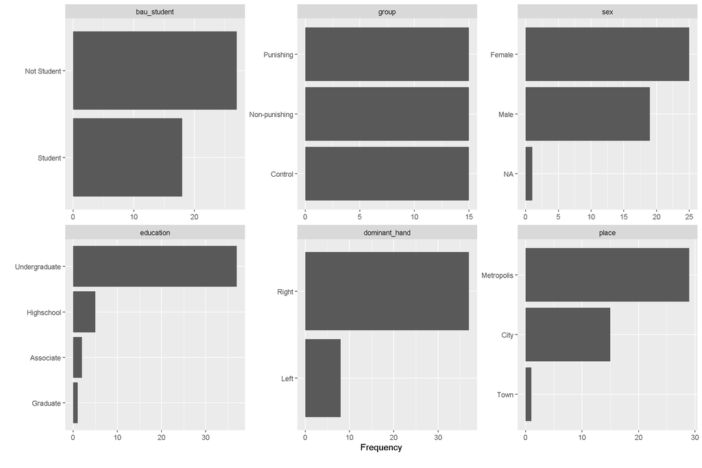

```r
DataExplorer::plot_bar(select(tez,
                              bau_student, group, sex,
                              education, dominant_hand, place))
```

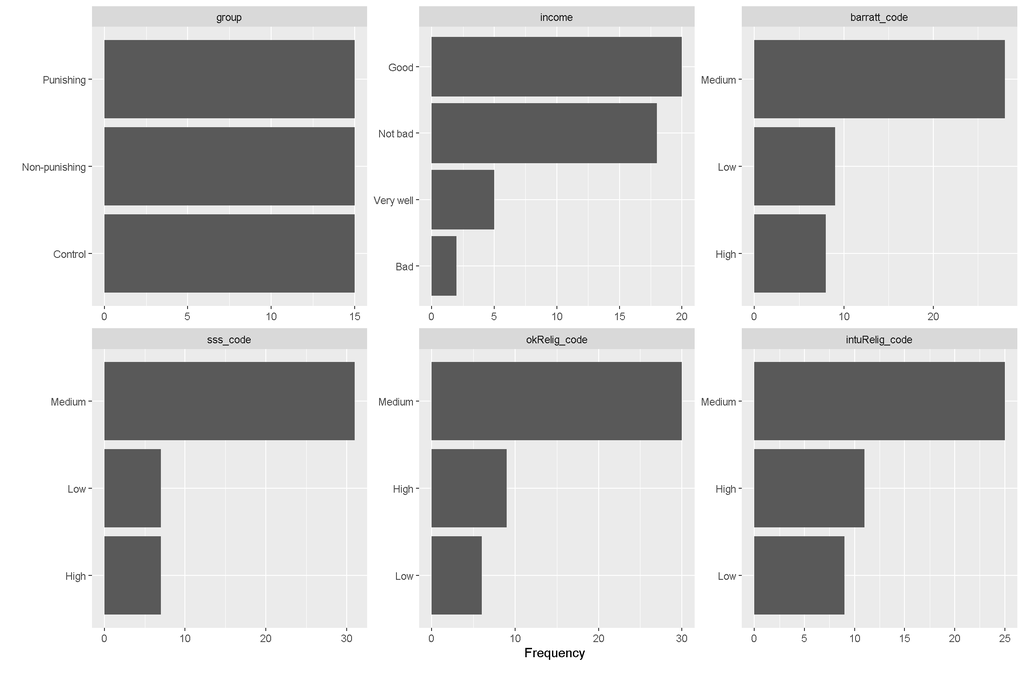

```r
DataExplorer::plot_bar(dplyr::select(tez,
                                     income, barratt_code, sss_code,
                                     okRelig_code, intuRelig_code))
```

### By Groups

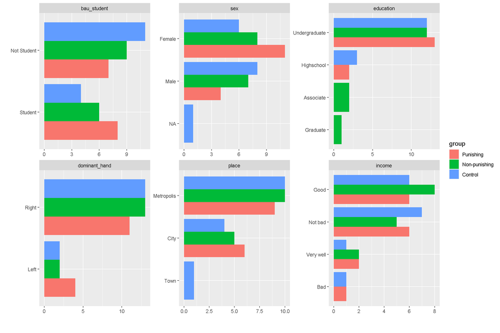

```r
DataExplorer::plot_bar(select(tez,
                              -barratt_code, -sss_code,
                              -okRelig_code, -intuRelig_code),
                       by = "group", by_position = "dodge")
```

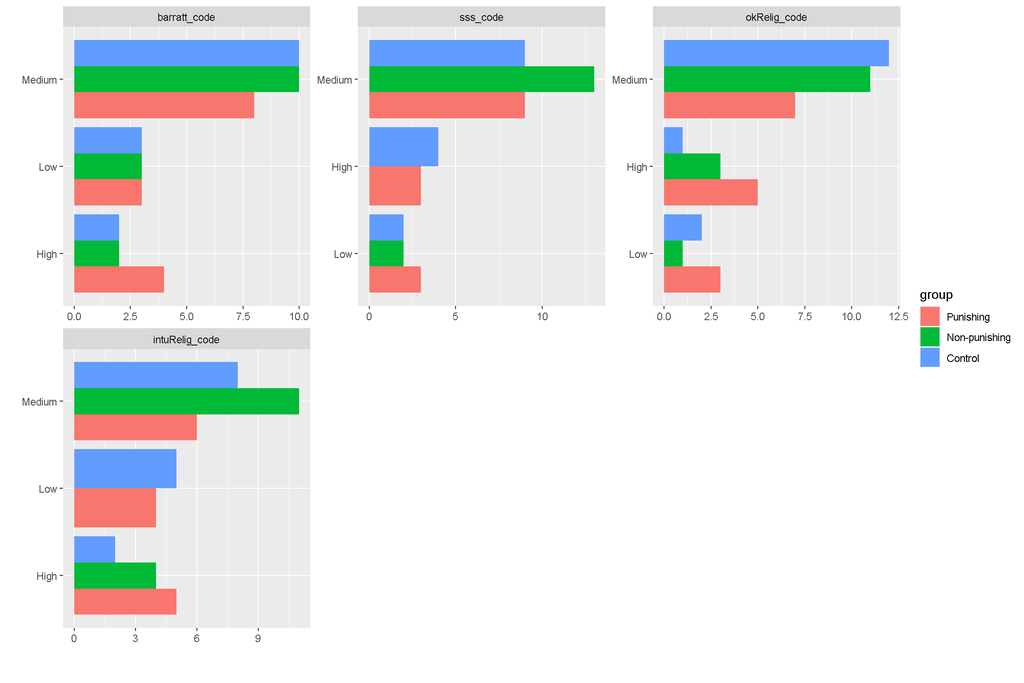

```r
DataExplorer::plot_bar(select(tez, -bau_student, -sex, -education,
                               -dominant_hand, -place, - income),
                       by = "group", by_position = "dodge")
```

## Analysis of Numeric Variables

```r
tez %>% dplyr::select(-id, -id_in_group) %>% ungroup() %>%
  diagnose_numeric() %>%
  flextable() %>% colformat_double(digits = 2) %>%
  footnote(i = 1, j = 8:9, inline = T, part = "header",
           value = as_paragraph(c("Number of values that are 0",
                                  "Number of negative values")))
```

| variables | min | Q1 | mean | median | Q3 | max | zero1 | minus2 | outlier |
| --- | --- | --- | --- | --- | --- | --- | --- | --- | --- |
| age | 18.00 | 22.00 | 23.71 | 23.00 | 26.00 | 31.00 | 0 | 0 | 0 |
| religion_rating | 1.00 | 3.00 | 4.31 | 4.00 | 5.00 | 7.00 | 0 | 0 | 0 |
| god_exists_rating | 45.00 | 85.00 | 88.67 | 95.00 | 100.00 | 100.00 | 0 | 0 | 4 |
| BART_awareness_1 | 5.00 | 15.00 | 25.64 | 20.00 | 30.00 | 150.00 | 0 | 0 | 2 |
| BART | 3.17 | 19.48 | 23.18 | 23.32 | 26.92 | 58.40 | 0 | 0 | 10 |
| BART_1 | 3.30 | 12.57 | 18.38 | 18.38 | 24.38 | 41.33 | 0 | 0 | 0 |
| BART_2 | 2.00 | 16.50 | 24.29 | 23.43 | 25.00 | 59.67 | 0 | 0 | 8 |
| BART_3 | 1.60 | 22.56 | 28.48 | 26.67 | 34.00 | 90.00 | 0 | 0 | 5 |
| IGT | -66.00 | -12.00 | 6.98 | 12.00 | 22.00 | 72.00 | 0 | 15 | 1 |
| IGT_1 | -14.00 | -4.00 | -1.24 | -2.00 | 2.00 | 14.00 | 8 | 23 | 3 |
| IGT_2 | -20.00 | -2.00 | -0.53 | 2.00 | 4.00 | 14.00 | 8 | 14 | 8 |
| IGT_3 | -16.00 | -8.00 | -0.36 | 0.00 | 4.00 | 20.00 | 5 | 18 | 0 |
| IGT_4 | -20.00 | -2.00 | 3.56 | 4.00 | 8.00 | 20.00 | 3 | 12 | 1 |
| IGT_5 | -12.00 | 0.00 | 5.56 | 6.00 | 8.00 | 20.00 | 1 | 11 | 0 |
| barratt_total | 19.00 | 27.00 | 31.89 | 34.00 | 37.00 | 41.00 | 0 | 0 | 0 |
| barratt_atten | 6.00 | 9.00 | 10.82 | 11.00 | 12.00 | 16.00 | 0 | 0 | 0 |
| barratt_motor | 7.00 | 9.00 | 11.24 | 11.00 | 13.00 | 16.00 | 0 | 0 | 0 |
| sss_total | 11.00 | 20.00 | 23.73 | 23.00 | 26.00 | 38.00 | 0 | 0 | 3 |
| okRelig_total | 14.00 | 22.00 | 25.69 | 25.00 | 28.00 | 39.00 | 0 | 0 | 1 |
| okRelig_cog | 3.00 | 7.00 | 7.51 | 7.00 | 9.00 | 10.00 | 0 | 0 | 1 |
| okRelig_feel | 2.00 | 4.00 | 5.13 | 5.00 | 6.00 | 10.00 | 0 | 0 | 1 |
| okRelig_behav | 2.00 | 5.00 | 5.84 | 6.00 | 7.00 | 10.00 | 0 | 0 | 0 |
| okRelig_rel2god | 3.00 | 6.00 | 7.20 | 7.00 | 9.00 | 10.00 | 0 | 0 | 0 |
| intuRelig_total | 15.00 | 18.00 | 20.58 | 21.00 | 23.00 | 25.00 | 0 | 0 | 0 |

1Number of values that are 0; 2Number of negative values

$~$

## Analysis for Outliers

```r
tez %>% ungroup() %>% dplyr::select(-id, -id_in_group) %>%
  diagnose_outlier() %>%
  flextable() %>% colformat_double(digits = 2) %>%
  footnote(i = 1, j = c(2, 5:6), inline = T, part = "header",
           value = as_paragraph(c("Outlier count",
                                  "Mean when outliers included",
                                  "Mean when outliers excluded")))
```

| variables | outliers_cnt1 | outliers_ratio | outliers_mean | with_mean2 | without_mean3 |
| --- | --- | --- | --- | --- | --- |
| age | 0 | 0.00 |  | 23.71 | 23.71 |
| religion_rating | 0 | 0.00 |  | 4.31 | 4.31 |
| god_exists_rating | 4 | 8.89 | 48.75 | 88.67 | 92.56 |
| BART_awareness_1 | 2 | 4.44 | 107.50 | 25.64 | 21.84 |
| BART | 10 | 22.22 | 25.09 | 23.18 | 22.64 |
| BART_1 | 0 | 0.00 |  | 18.38 | 18.38 |
| BART_2 | 8 | 17.78 | 44.46 | 24.29 | 19.93 |
| BART_3 | 5 | 11.11 | 47.08 | 28.48 | 26.15 |
| IGT | 1 | 2.22 | -66.00 | 6.98 | 8.64 |
| IGT_1 | 3 | 6.67 | 4.67 | -1.24 | -1.67 |
| IGT_2 | 8 | 17.78 | -11.75 | -0.53 | 1.89 |
| IGT_3 | 0 | 0.00 |  | -0.36 | -0.36 |
| IGT_4 | 1 | 2.22 | -20.00 | 3.56 | 4.09 |
| IGT_5 | 0 | 0.00 |  | 5.56 | 5.56 |
| barratt_total | 0 | 0.00 |  | 31.89 | 31.89 |
| barratt_atten | 0 | 0.00 |  | 10.82 | 10.82 |
| barratt_motor | 0 | 0.00 |  | 11.24 | 11.24 |
| sss_total | 3 | 6.67 | 37.33 | 23.73 | 22.76 |
| okRelig_total | 1 | 2.22 | 39.00 | 25.69 | 25.39 |
| okRelig_cog | 1 | 2.22 | 3.00 | 7.51 | 7.61 |
| okRelig_feel | 1 | 2.22 | 10.00 | 5.13 | 5.02 |
| okRelig_behav | 0 | 0.00 |  | 5.84 | 5.84 |
| okRelig_rel2god | 0 | 0.00 |  | 7.20 | 7.20 |
| intuRelig_total | 0 | 0.00 |  | 20.58 | 20.58 |

1Outlier count; 2Mean when outliers included; 3Mean when outliers excluded

$~$

## Outcome Variable Statistics by Groups

### IGT

```r
by(tez$IGT, tez$group,
   stat.desc, basic = F, norm = T)
```

```
tez$group: Punishing
      median         mean      SE.mean CI.mean.0.95          var      std.dev
   8.0000000    6.5333333    8.0082497   17.1759874  961.9809524   31.0158178
    coef.var     skewness     skew.2SE     kurtosis     kurt.2SE   normtest.W
   4.7473190   -0.2482109   -0.2139309    0.4632929    0.2066617    0.9508008
  normtest.p
   0.5371517
------------------------------------------------------------
tez$group: Non-punishing
      median         mean      SE.mean CI.mean.0.95          var      std.dev
   8.0000000    0.9333333    7.0342473   15.0869599  742.2095238   27.2435226
    coef.var     skewness     skew.2SE     kurtosis     kurt.2SE   normtest.W
  29.1894885   -0.3053115   -0.2631454   -0.7081537   -0.3158870    0.9665297
  normtest.p
   0.8037616
------------------------------------------------------------
tez$group: Control
      median         mean      SE.mean CI.mean.0.95          var      std.dev
 20.00000000  13.46666667   5.69533365  12.21527580 486.55238095  22.05793238
    coef.var     skewness     skew.2SE     kurtosis     kurt.2SE   normtest.W
  1.63796528   0.13788264   0.11883989  -0.03570031  -0.01592488   0.90843380
  normtest.p
  0.12812505
```

$~$

### BART

```r
by(tez$BART, tez$group,
   stat.desc, basic = F, norm = T)
```

```
tez$group: Punishing
      median         mean      SE.mean CI.mean.0.95          var      std.dev
 26.65217391  26.05344285   2.94580858   6.31813102 130.16682248  11.40906756
    coef.var     skewness     skew.2SE     kurtosis     kurt.2SE   normtest.W
  0.43791017   0.95572232   0.82372904   2.43023891   1.08405980   0.83402082
  normtest.p
  0.01039779
------------------------------------------------------------
tez$group: Non-punishing
      median         mean      SE.mean CI.mean.0.95          var      std.dev
 23.32000000  21.97430795   3.12543849   6.70339887 146.52548650  12.10477123
    coef.var     skewness     skew.2SE     kurtosis     kurt.2SE   normtest.W
  0.55086018   0.09458838   0.08152493  -1.12922548  -0.50371506   0.95911590
  normtest.p
  0.67703245
------------------------------------------------------------
tez$group: Control
      median         mean      SE.mean CI.mean.0.95          var      std.dev
 21.56000000  21.51618847   2.79709504   5.99917221 117.35611010  10.83310251
    coef.var     skewness     skew.2SE     kurtosis     kurt.2SE   normtest.W
  0.50348613   0.56743528   0.48906770  -0.11051046  -0.04929554   0.90817969
  normtest.p
  0.12698079
```

**Interesting Points:**

- Punishing primes group is a little over 1 in its kurtosis statistic (kurt.2SE = 1.08). *What to do about it?*

$~$

## Plots

### IGT

#### Line Plot

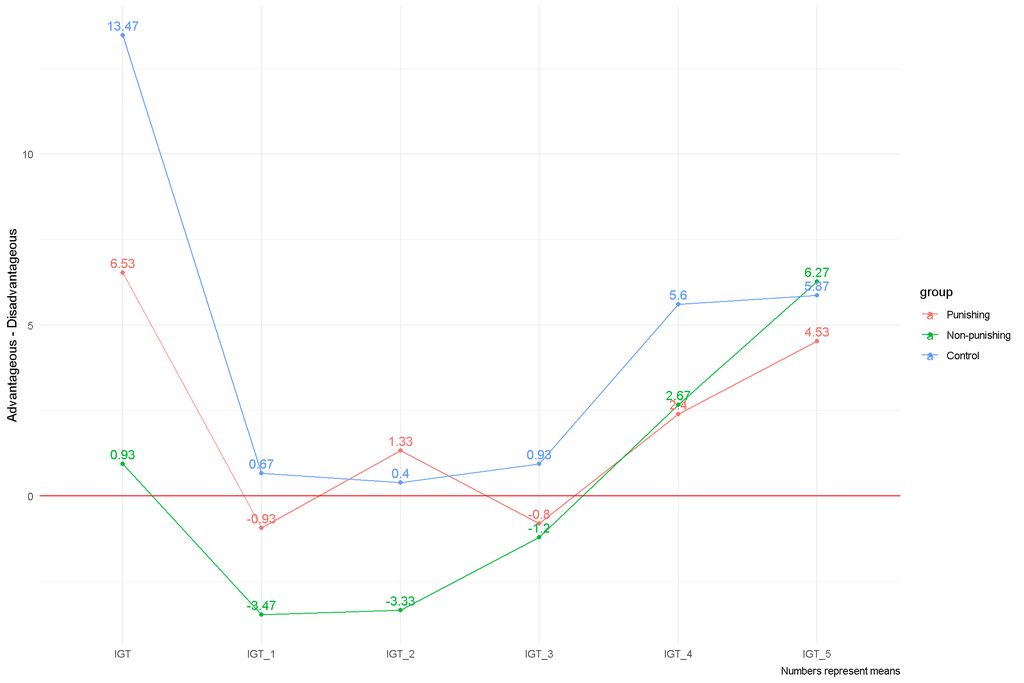

```r
tez %>% tidyr::pivot_longer(cols = contains("IGT"),
                            names_to = "igt_blocks",
                            values_to = "score") %>%
  ggplot(aes(igt_blocks, score, group = group, color = group)) +
  stat_summary(fun.y = mean, geom = "point") +
  stat_summary(fun.y = mean, geom = "line") +
  stat_summary(aes(label = round(..y.., 2)),
                   fun.y = mean, geom = "text", vjust = -.5) +
  geom_hline(aes(yintercept = 0), color = "red", liIGType = "dotted") +
  theme_minimal() +
  labs(x = NULL,
       y = "Advantageous - Disadvantageous",
       caption = "Numbers represent means")
```

$~$

#### Bar Plot

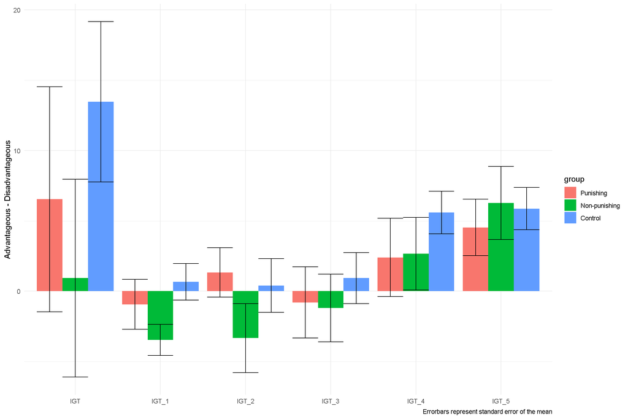

```r
tez %>% pivot_longer(col = contains("IGT"),
                     names_to = "igt_blocks",
                     values_to = "score") %>%
  ggplot(aes(igt_blocks, score, fill = group)) +
  stat_summary(fun = mean, geom = "bar", position = "dodge") +
  stat_summary(fun.data = mean_se, geom = "errorbar", position = "dodge") +
  theme_minimal() +
  labs(x = NULL,
       y = "Advantageous - Disadvantageous",
       caption = "Errorbars represent standard error of the mean")
```

### BART

#### Line Plot

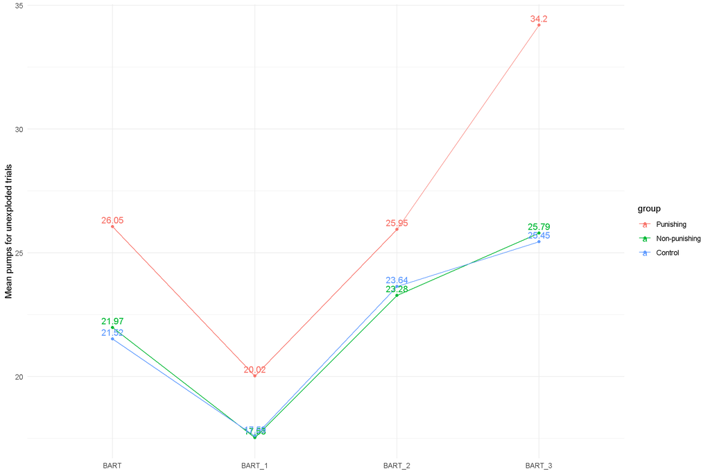

```r
tez %>% dplyr::select(-BART_awareness_1) %>%
  pivot_longer(cols = contains("BART"),
               names_to = "bart_blocks",
               values_to = "score") %>%
  ggplot(aes(bart_blocks, score, group = group, color = group)) +
  stat_summary(fun.y = mean, geom = "point") +
  stat_summary(fun.y = mean, geom = "line") +
  stat_summary(aes(label = round(..y.., 2)),
               fun.y = mean, geom = "text", vjust = -.5) +
  theme_minimal() +
  labs(x = NULL,
       y = "Mean pumps for unexploded trials")
```

$~$

#### Bar Plot

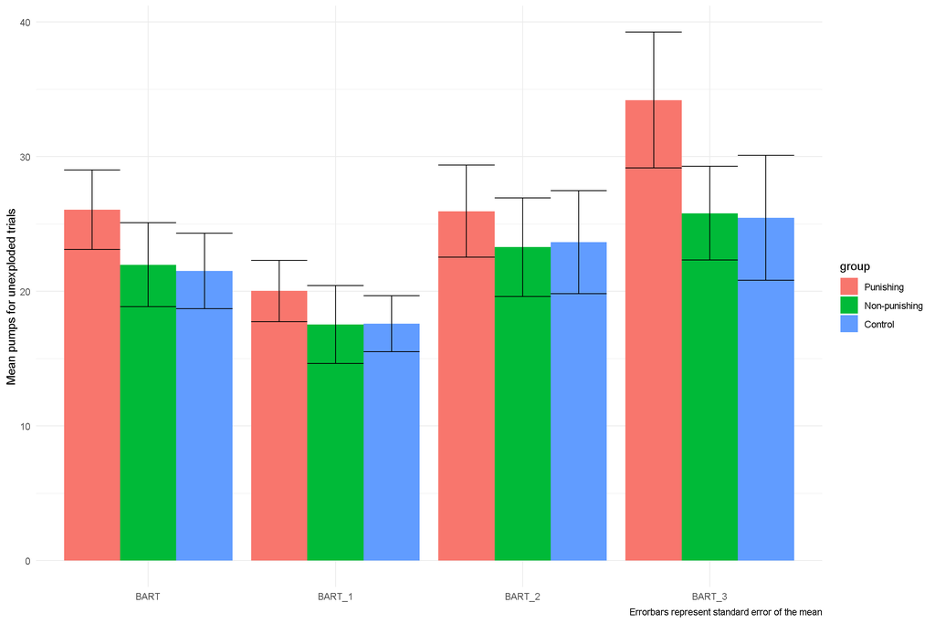

```r
tez %>% dplyr::select(-BART_awareness_1) %>%
  pivot_longer(cols = contains("BART"),
               names_to = "bart_blocks",
               values_to = "score") %>%
  ggplot(aes(bart_blocks, score, fill = group)) +
  stat_summary(fun = mean, geom = "bar", position = "dodge") +
  stat_summary(fun.data = mean_se, geom = "errorbar", position = "dodge") +
  theme_minimal() +
  labs(x = NULL,
       y = "Mean pumps for unexploded trials",
       caption = "Errorbars represent standard error of the mean")
```

$~$

## Correlations

### Correlation Plot

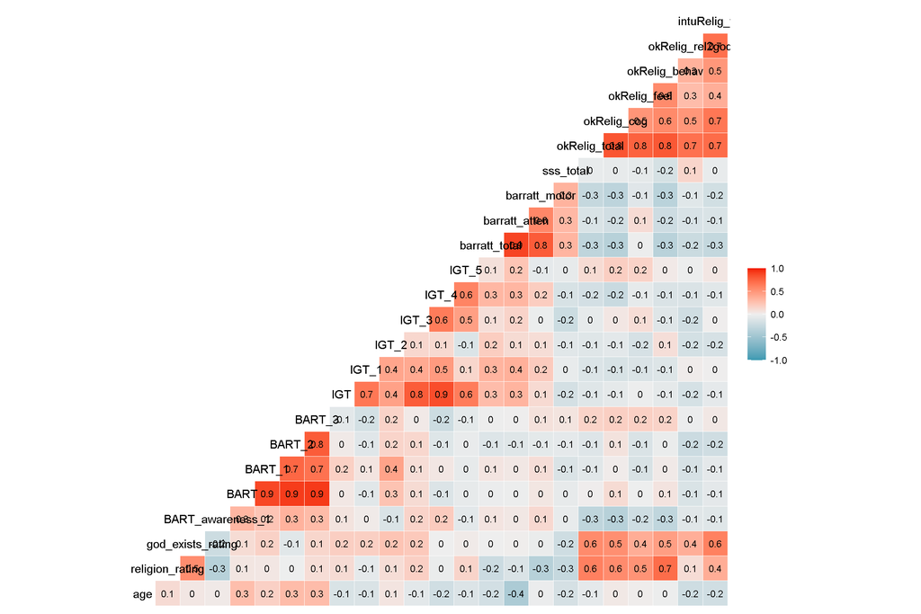

```r
tez %>% select(-id, -id_in_group) %>%
  GGally::ggcorr(label = T, label_size = 3)
```

$~$

### Correlation Matrix

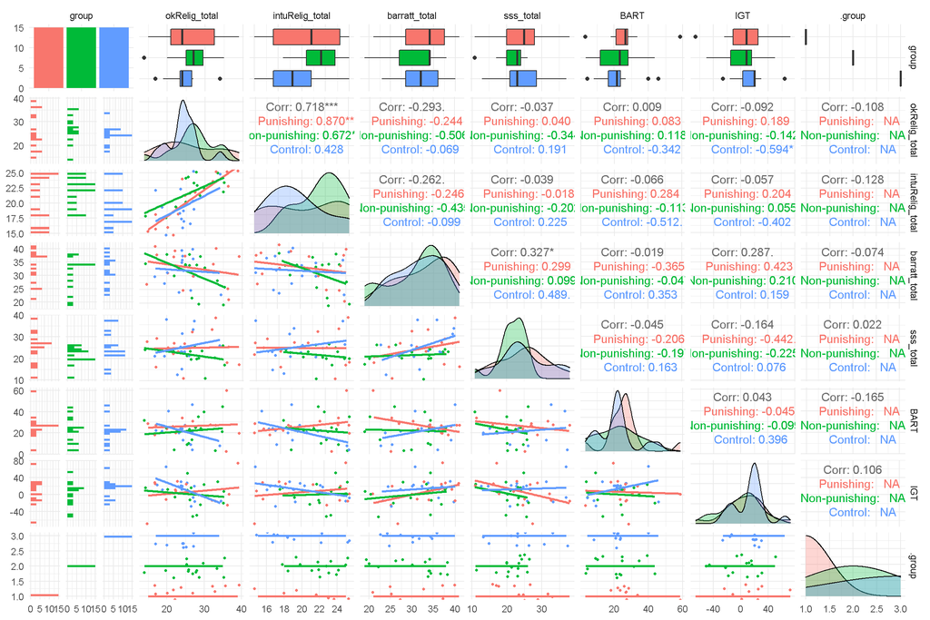

```r
tez %>% select(okRelig_total, intuRelig_total,
               barratt_total, sss_total,
               BART, IGT) %>%
  GGally::ggpairs(mapping = ggplot2::aes(color = tez$group),
                  lower = list(continuous = wrap("smooth", size = .9,
                                                 position = "jitter",
                                                 se = F,
                                                 method = "lm")),
                  diag = list(continuous = wrap("densityDiag",
                                                alpha = .3))) +
  theme_minimal()
```

$~$

### Interactive Correlation Tables

You can sort the table in ascending or descending order by clicking on the column names.

#### All

```r
tez %>% ungroup() %>% dplyr::select(-id, -id_in_group) %>%
correlate() %>%
  reactable::reactable(compact = T, highlight = T,
    defaultColDef = colDef(format =
                             colFormat(separators = T, digits = 3)
                          )
                      )
```

| var1 | var2 | coef_corr |
| --- | --- | --- |
| religion_rating | age | 0.113958097989976 |
| god_exists_rating | age | 0.0456763696982052 |
| BART_awareness_1 | age | 0.0270804327605699 |
| BART | age | 0.278015232893369 |
| BART_1 | age | 0.171980354737339 |
| BART_2 | age | 0.290281573710486 |
| BART_3 | age | 0.28581308828594 |
| IGT | age | -0.128403234105746 |
| IGT_1 | age | -0.124092255485758 |
| IGT_2 | age | 0.0558465183995262 |

[output cut: 542 more lines]

$~$

#### By Groups

```r
tez %>% dplyr::select(-id, -id_in_group) %>%
correlate() %>%
  reactable::reactable(compact = T, highlight = T,
    defaultColDef = colDef(format =
                             colFormat(separators = T, digits = 3)
                          )
                      )
```

| group | var1 | var2 | coef_corr |
| --- | --- | --- | --- |
| Punishing | religion_rating | age | -0.0707536038287295 |
| Punishing | god_exists_rating | age | 0.0992102774563327 |
| Punishing | BART_awareness_1 | age | 0.456229757739212 |
| Punishing | BART | age | 0.477092636087451 |
| Punishing | BART_1 | age | 0.384710611105309 |
| Punishing | BART_2 | age | 0.485949544530734 |
| Punishing | BART_3 | age | 0.394095739198128 |
| Punishing | IGT | age | -0.0985716482688009 |
| Punishing | IGT_1 | age | -0.070500751681566 |
| Punishing | IGT_2 | age | 0.0606698988410624 |

[output cut: 1646 more lines]

$~$

# ANCOVA Model

$~$

## Assumptions

### 1. Indipendence of Covariates from the IV

> ANCOVA assumes that the covarite is not related to the independent variable.

We can check this assumption by creating an ANOVA model with the covariate as the DV and the religious priming groups as the IV in our study.

#### Impulsiveness

```r
summary(aov(barratt_total ~ group, data = tez))
```

```
            Df Sum Sq Mean Sq F value Pr(>F)
group        2   38.6   19.29   0.534   0.59
Residuals   42 1517.9   36.14
```

```r
report(aov(barratt_total ~ group, data = tez))
```

```
The ANOVA (formula: barratt_total ~ group) suggests that:

  - The main effect of group is statistically not significant and small (F(2, 42) = 0.53, p = 0.590; Eta2 = 0.02, 90% CI [0.00, 0.12])

Effect sizes were labelled following Field's (2013) recommendations.
```

We can assume that the covariate of impulsiveness is not influenced by our manipulations, therefore independent of the IV.

$~$

#### Sensation-seeking

```r
summary(aov(sss_total ~ group, data = tez))
```

```
            Df Sum Sq Mean Sq F value Pr(>F)
group        2  109.7   54.87   1.425  0.252
Residuals   42 1617.1   38.50
```

```r
report(aov(sss_total ~ group, data = tez))
```

```
The ANOVA (formula: sss_total ~ group) suggests that:

  - The main effect of group is statistically not significant and medium (F(2, 42) = 1.43, p = 0.252; Eta2 = 0.06, 90% CI [0.00, 0.19])

Effect sizes were labelled following Field's (2013) recommendations.
```

We can assume that the covariate of sensation-seeking is not influenced by our manipulations, therefore independent of the IV.

$~$

### 2. Homogeniety of Regression Slopes

> ANCOVA assumes that the slopes of the regression lines, formed by the covariate and the outcome variable, should be the same for each group.

We can check this assumption by looking for non-significant interaction between the covariate and the IV groups.

#### IGT

```r
car::Anova(aov(IGT ~ group:barratt_total:sss_total, data = tez))
```

```
Anova Table (Type II tests)

Response: IGT
                               Sum Sq Df F value Pr(>F)
group:barratt_total:sss_total  1202.1  3   0.536 0.6602
Residuals                     30650.9 41
```

```r
report(aov(IGT ~ group:barratt_total:sss_total, data = tez))
```

```
The ANOVA (formula: IGT ~ group:barratt_total:sss_total) suggests that:

  - The interaction between group, barratt_total and sss_total is statistically not significant and small (F(3, 41) = 0.54, p = 0.660; Eta2 = 0.04, 90% CI [0.00, 0.11])

Effect sizes were labelled following Field's (2013) recommendations.
```

Since there were no significant interactions between the IV and the covarite, we can assume homogeneity of regression slopes.

$~$

#### BART

```r
car::Anova(aov(BART ~ group:barratt_total:sss_total, data = tez))
```

```
Anova Table (Type II tests)

Response: BART
                              Sum Sq Df F value Pr(>F)
group:barratt_total:sss_total  108.9  3   0.266 0.8495
Residuals                     5595.0 41
```

```r
report(aov(BART ~ group:barratt_total:sss_total, data = tez))
```

```
The ANOVA (formula: BART ~ group:barratt_total:sss_total) suggests that:

  - The interaction between group, barratt_total and sss_total is statistically not significant and small (F(3, 41) = 0.27, p = 0.849; Eta2 = 0.02, 90% CI [0.00, 0.06])

Effect sizes were labelled following Field's (2013) recommendations.
```

Since there were no significant interactions between the IV and the covarite, we can assume homogeneity of regression slopes.

$~$

### 3. Homogeneity of Variances (Heteroscasdicity)

> ANCOVA assumes that residual variances for the outcome variable are homogeneous for all groups.

We can check for this assumption applying Levene’s test.

$~$

#### IGT

```r
igt_anova <- aov(IGT ~ group, data =tez)

car::leveneTest(IGT ~ group, data = tez, center = median)
```

```
Levene's Test for Homogeneity of Variance (center = median)
      Df F value Pr(>F)
group  2  0.6507 0.5268
      42
```

```r
check_homogeneity(igt_anova, method = "levene")
```

```
OK: Variances in each of the groups are the same (Levene's Test, p = 0.527).
 OK: Variances in each of the groups are the same (Levene's Test, p = NA).
```

Since the Levene’s test suggests that residual variance distributions do not differ between groups (p > .05), we can assume homoscasdicity.

$~$

#### BART

```r
bart_anova <- aov(BART ~ group, data = tez)

car::leveneTest(BART ~ group, data = tez, center = median)
```

```
Levene's Test for Homogeneity of Variance (center = median)
      Df F value Pr(>F)
group  2  0.4202 0.6597
      42
```

```r
check_homogeneity(bart_anova, method = "levene")
```

```
OK: Variances in each of the groups are the same (Levene's Test, p = 0.660).
 OK: Variances in each of the groups are the same (Levene's Test, p = NA).
```

Since the Levene’s test suggests that residual variance distributions do not differ between groups (p > .05), we can assume homoscasdicity.

$~$

### 4. Normality of Residuals

> ANCOVA assumes that the outcome variable is normally distributed.

We can check this with Shapiro-Wilk test of normality and visualize distribution plots.

$~$

#### IGT

Shapiro-Wilk normality tests of the IGT results for groups:

```r
by(tez$IGT, tez$group, shapiro.test)
```

```
tez$group: Punishing

    Shapiro-Wilk normality test

data:  dd[x, ]
W = 0.9508, p-value = 0.5372

------------------------------------------------------------
tez$group: Non-punishing

    Shapiro-Wilk normality test

data:  dd[x, ]
W = 0.96653, p-value = 0.8038

------------------------------------------------------------
tez$group: Control

    Shapiro-Wilk normality test

data:  dd[x, ]
W = 0.90843, p-value = 0.1281
```

$~$

Shapiro-Wilk normality test for the IGT ANCOVA model:

```
OK: residuals appear as normally distributed (p = 0.084).
```

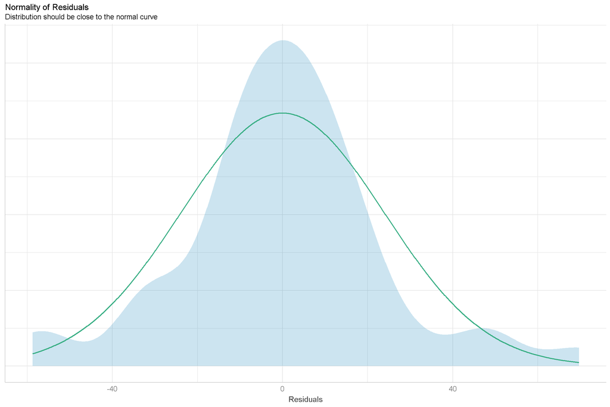

```r
igt_full_ancova <- aov(IGT ~ barratt_total + sss_total + group, data = tez)

plot(check_normality(igt_full_ancova))
```

$~$

#### BART

Shapiro-Wilk normality tests of the BART results for groups:

```r
by(tez$BART, tez$group, shapiro.test)
```

```
tez$group: Punishing

    Shapiro-Wilk normality test

data:  dd[x, ]
W = 0.83402, p-value = 0.0104

------------------------------------------------------------
tez$group: Non-punishing

    Shapiro-Wilk normality test

data:  dd[x, ]
W = 0.95912, p-value = 0.677

------------------------------------------------------------
tez$group: Control

    Shapiro-Wilk normality test

data:  dd[x, ]
W = 0.90818, p-value = 0.127
```

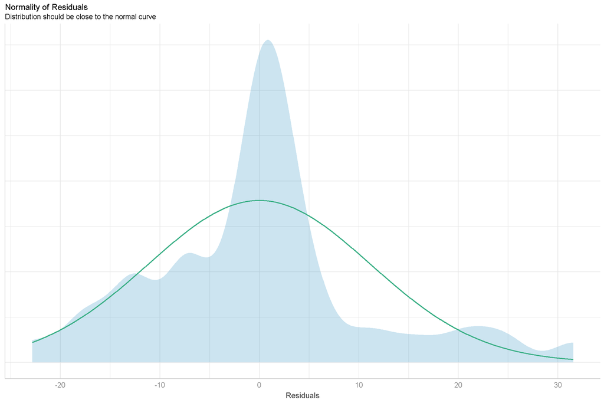

```r
bart_ancova_full <- aov(BART ~ BART + sss_total + group, data = tez)

plot(check_normality(bart_ancova_full))
```

$~$

### 5. Linearity

> ANCOVA assumes linearity between the covariate and the outcome variable at each level of the grouping variable.

This can be checked by creating a grouped scatter plot of the covariate and the outcome variable.

#### IGT

##### Impulsivity and IGT

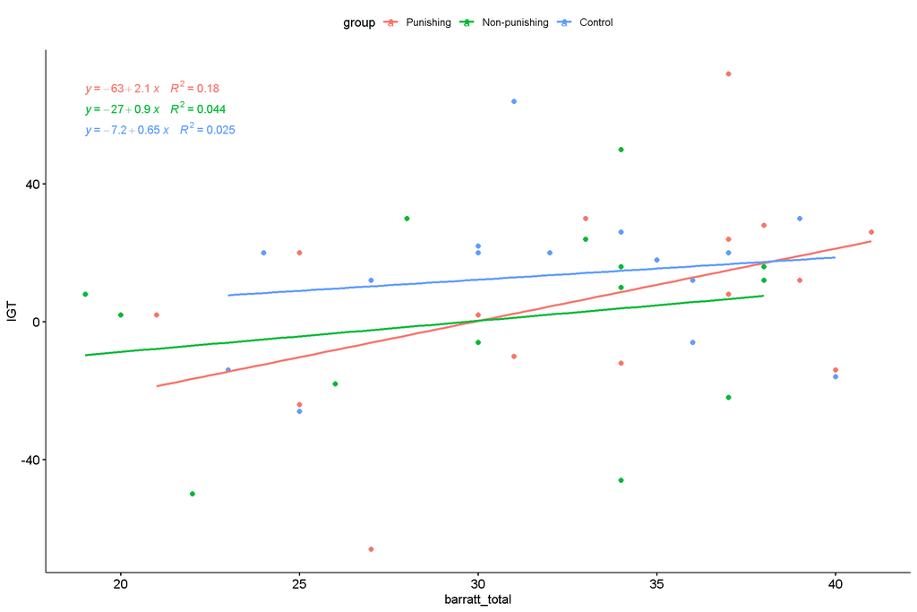

```r
ggscatter(tez,
          x = "barratt_total", y = "IGT",
          color = "group", add = "reg.line") +
  stat_regline_equation(
    aes(label =  paste(..eq.label.., ..rr.label.., sep = "~~~~"), color = group)
  )
```

##### Sensation-seeking and IGT

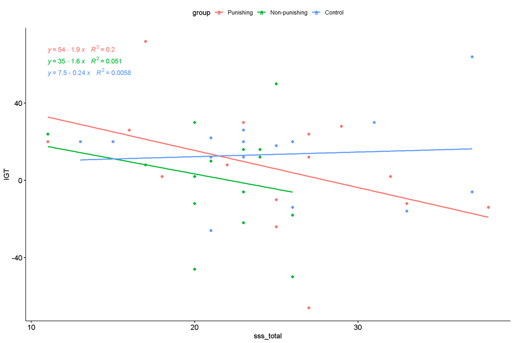

```r
ggscatter(tez,
          x = "sss_total", y = "IGT",
          color = "group", add = "reg.line") +
  stat_regline_equation(
    aes(label = paste(..eq.label.., ..rr.label.., sep = "~~~~"), color = group)
  )
```

$~$

#### BART

##### Impulsivity and BART

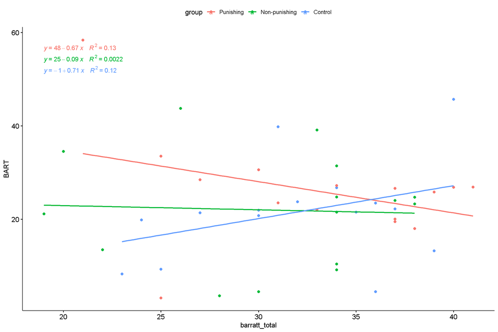

```r
ggscatter(tez,
          x = "barratt_total", y = "BART",
          color = "group", add = "reg.line") +
  stat_regline_equation(
    aes(label =  paste(..eq.label.., ..rr.label.., sep = "~~~~"), color = group)
  )
```

##### Sensation-seeking and BART

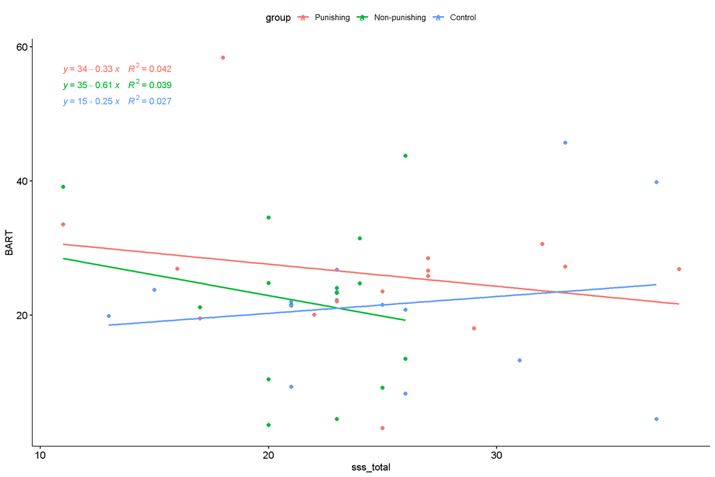

```r
ggscatter(tez,
          x = "sss_total", y = "BART",
          color = "group", add = "reg.line") +
  stat_regline_equation(
    aes(label = paste(..eq.label.., ..rr.label.., sep = "~~~~"), color = group)
  )
```

$~$

### Outliers

> ANCOVA assumes no significant outliers in the groups.

We can check for outliers using the IQR method.

$~$

#### IGT

```r
tez %>% dplyr::group_by(group) %>% dplyr::select(contains("IGT")) %>% diagnose_outlier() %>%
  flextable() %>% colformat_double(digits = 2)%>%
  footnote(i = 1:12, j = 1, inline = T,
           value = as_paragraph(c("Punishing","Non-punishing","Control")))
```

| variables | outliers_cnt | outliers_ratio | outliers_mean | with_mean | without_mean |
| --- | --- | --- | --- | --- | --- |
| IGT1 | 1 | 6.67 | -66.00 | 6.53 | 11.71 |
| IGT2 | 0 | 0.00 |  | 0.93 | 0.93 |
| IGT3 | 2 | 13.33 | 19.00 | 13.47 | 12.62 |
| IGT_11 | 0 | 0.00 |  | -0.93 | -0.93 |
| IGT_12 | 1 | 6.67 | -14.00 | -3.47 | -2.71 |
| IGT_13 | 3 | 20.00 | 0.00 | 0.67 | 0.83 |
| IGT_21 | 3 | 20.00 | -3.33 | 1.33 | 2.50 |
| IGT_22 | 0 | 0.00 |  | -3.33 | -3.33 |
| IGT_23 | 2 | 13.33 | -14.00 | 0.40 | 2.62 |
| IGT_31 | 0 | 0.00 |  | -0.80 | -0.80 |
| IGT_32 | 0 | 0.00 |  | -1.20 | -1.20 |
| IGT_33 | 1 | 6.67 | -14.00 | 0.93 | 2.00 |
| IGT_4 | 0 | 0.00 |  | 2.40 | 2.40 |
| IGT_4 | 0 | 0.00 |  | 2.67 | 2.67 |
| IGT_4 | 1 | 6.67 | 20.00 | 5.60 | 4.57 |
| IGT_5 | 0 | 0.00 |  | 4.53 | 4.53 |
| IGT_5 | 0 | 0.00 |  | 6.27 | 6.27 |
| IGT_5 | 1 | 6.67 | 20.00 | 5.87 | 4.86 |

1Punishing; 2Non-punishing; 3Control

```r
# Shiny

by(tez$IGT, tez$group, check_outliers, method = "iqr")
```

```
tez$group: Punishing
Warning: 1 outliers detected (cases 10).
------------------------------------------------------------
tez$group: Non-punishing
OK: No outliers detected.
------------------------------------------------------------
tez$group: Control
Warning: 2 outliers detected (cases 10, 13).
```

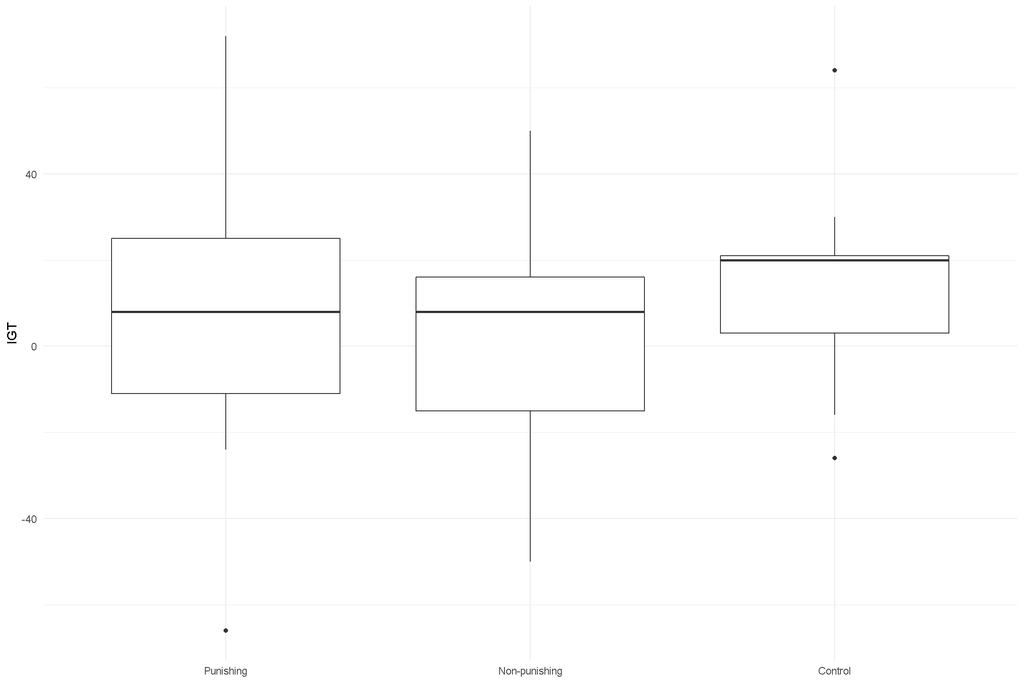

```r
tez %>% ggplot(aes(group, IGT)) + geom_boxplot() + theme_minimal() + labs(x = NULL)
```

#### BART

```r
tez %>% dplyr::group_by(group) %>% dplyr::select(contains("BART"), -BART_awareness_1) %>% diagnose_outlier() %>%
  flextable() %>% colformat_double(digits = 2) %>%
  footnote(i = 1:12, j = 1, inline = T,
           value = as_paragraph(c("Punishing","Non-punishing","Control")))
```

| variables | outliers_cnt | outliers_ratio | outliers_mean | with_mean | without_mean |
| --- | --- | --- | --- | --- | --- |
| BART1 | 2 | 13.33 | 30.79 | 26.05 | 25.33 |
| BART2 | 0 | 0.00 |  | 21.97 | 21.97 |
| BART3 | 3 | 20.00 | 30.01 | 21.52 | 19.39 |
| BART_11 | 1 | 6.67 | 41.33 | 20.02 | 18.50 |
| BART_12 | 0 | 0.00 |  | 17.53 | 17.53 |
| BART_13 | 0 | 0.00 |  | 17.59 | 17.59 |
| BART_21 | 3 | 20.00 | 36.50 | 25.95 | 23.31 |
| BART_22 | 0 | 0.00 |  | 23.28 | 23.28 |
| BART_23 | 2 | 13.33 | 56.96 | 23.64 | 18.52 |
| BART_31 | 2 | 13.33 | 45.80 | 34.20 | 32.41 |
| BART_32 | 1 | 6.67 | 57.80 | 25.79 | 23.50 |
| BART_33 | 1 | 6.67 | 81.00 | 25.45 | 21.48 |

1Punishing; 2Non-punishing; 3Control

```r
by(tez$BART, tez$group, check_outliers, method = "iqr")
```

```
tez$group: Punishing
Warning: 2 outliers detected (cases 2, 9).
------------------------------------------------------------
tez$group: Non-punishing
OK: No outliers detected.
------------------------------------------------------------
tez$group: Control
Warning: 3 outliers detected (cases 6, 8, 13).
```

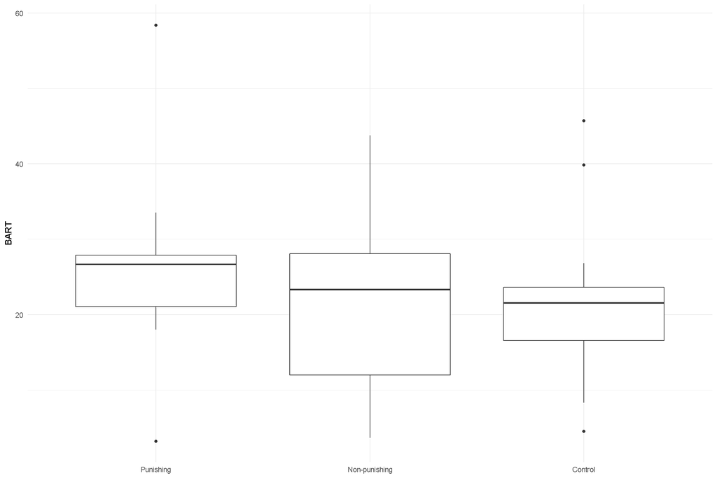

```r
tez %>% ggplot(aes(group, BART)) + geom_boxplot() + theme_minimal() + labs(x = NULL)
```

ANCOVA is quite sensitive to outliers. We need to deal with these values somehow.

$~$

### Model Assumption Visualizations

$~$

These are the assumptions for the full ANCOVA (controlling for impulsivity and sensation-seeking) models.

$~$

#### IGT

##### Plot 1

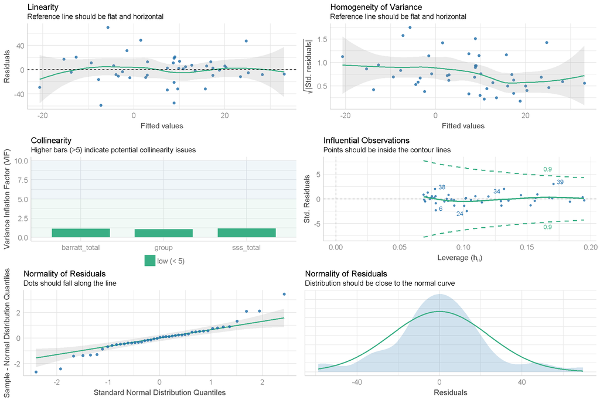

```r
check_model(aov(IGT ~ barratt_total + sss_total + group, data = tez))
```

$~$

##### Plot 2

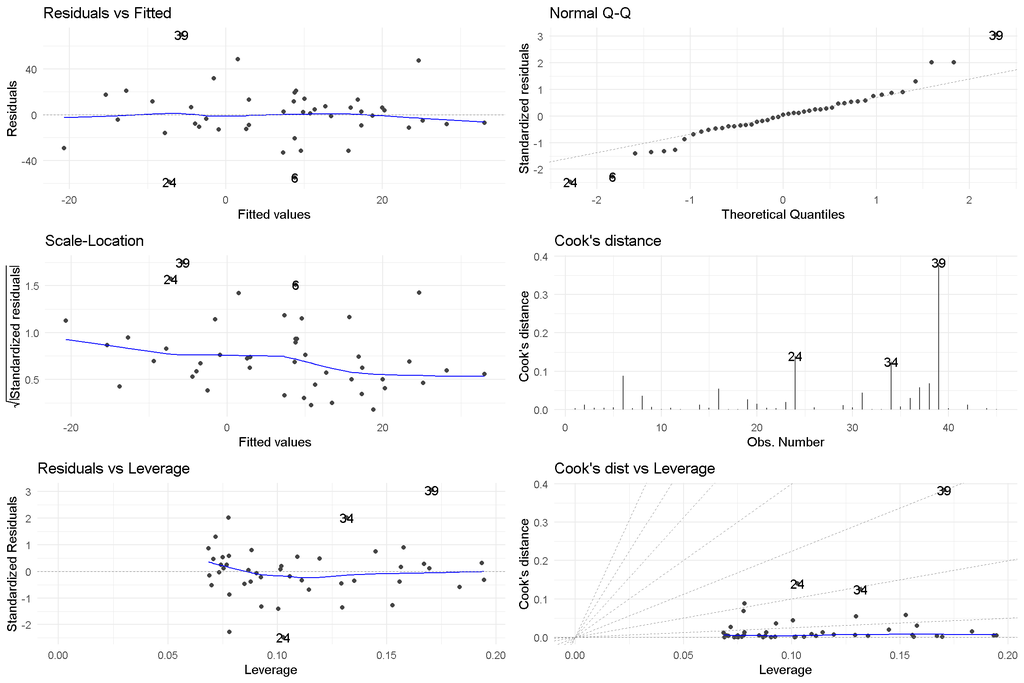

```r
autoplot(igt_full_ancova, which = 1:6, nrow = 3, ncol = 2) + theme_minimal()
```

$~$

##### Metrics

```r
igt_full_ancova %>% augment(data = tez) %>%
  dplyr::select(id, IGT, barratt_total, sss_total,
                .fitted:.std.resid) %>%
  reactable(compact = T, highlight = T, striped = T,
            columns = list(id = colDef(format = colFormat(digits = 0)),
                           IGT = colDef(format = colFormat(digits = 0)),
                           barratt_total = colDef(format = colFormat(digits = 0)),
                           sss_total = colDef(format = colFormat(digits = 0))),
            defaultColDef = colDef(
              format = colFormat(separators = T, digits = 3)))
```

| id | IGT | barratt_total | sss_total | .fitted | .resid | .hat | .sigma | .cooksd | .std.resid |
| --- | --- | --- | --- | --- | --- | --- | --- | --- | --- |
| 1 | 8 | 37 | 22 | 17.341630490316 | -9.34163049031597 | 0.0877781890534039 | 25.3280223522308 | 0.00293221950811233 | -0.390337394743083 |
| 2 | -24 | 25 | 25 | -7.76871484427847 | -16.2312851557215 | 0.114452025523198 | 25.2256475675829 | 0.0122481502892604 | -0.688358312103018 |
| 3 | 26 | 41 | 16 | 33.0262917382008 | -7.02629173820084 | 0.19451991865013 | 25.3454148073805 | 0.00471489712763248 | -0.312439889763752 |
| 4 | 16 | 34 | 24 | 2.96570871154534 | 13.0342912884547 | 0.0750956019234253 | 25.2834273864424 | 0.00475073772167209 | 0.540887195451996 |
| 5 | -14 | 23 | 26 | -3.42233570211978 | -10.5776642978802 | 0.129268141303546 | 25.3113967974104 | 0.00607669712057156 | -0.452392360766854 |
| 6 | -46 | 34 | 20 | 8.81734562062805 | -54.817345620628 | 0.0782026232408761 | 23.6722444969945 | 0.0880951068025996 | -2.27859934731814 |
| 7 | 20 | 30 | 26 | 8.66527459533662 | 11.3347254046634 | 0.0709052968797273 | 25.3064410030233 | 0.00336160061623623 | 0.469298008969213 |
| 8 | -22 | 37 | 23 | 9.60902235201161 | -31.6090223520116 | 0.0927236817975225 | 24.8137997592632 | 0.0358508156992881 | -1.3243689083505 |
| 9 | 2 | 30 | 32 | -9.37507207984721 | 11.3750720798472 | 0.119456068913814 | 25.3020508446301 | 0.00635008989643917 | 0.483778254934462 |
| 10 | 26 | 34 | 23 | 19.9612081614095 | 6.03879183859054 | 0.0742939673276306 | 25.3564887840813 | 0.00100710065364619 | 0.250484705314448 |

[output cut: 35 more lines]

$~$

#### BART

$~$

These are the assumptions for the full ANCOVA (controlling for impulsivity and sensation-seeking) models.

$~$

##### Plot 1

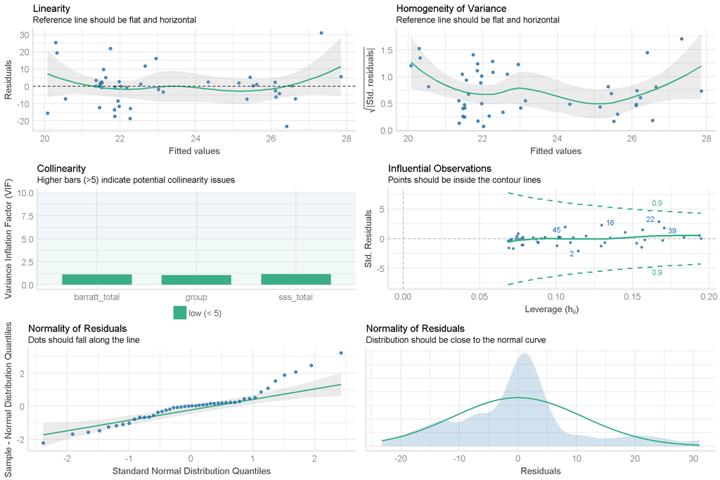

```r
check_model(aov(BART ~ barratt_total + sss_total + group, data = tez))
```

$~$

##### Plot 2

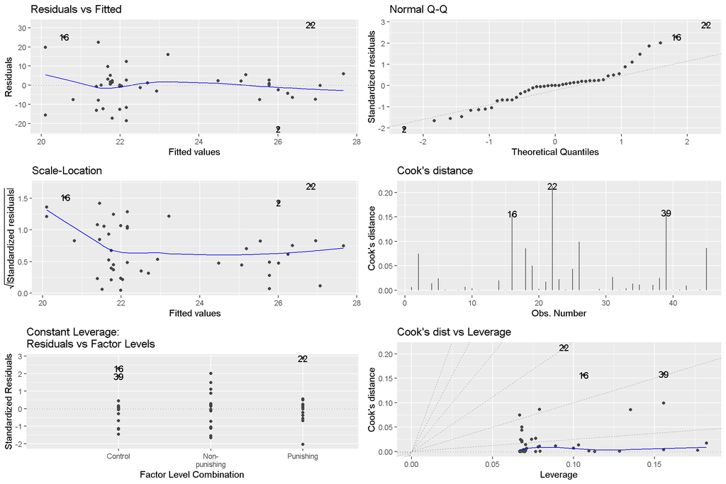

```r
autoplot(bart_ancova_full, which = 1:6, nrow = 3, ncol = 2)
```

$~$

##### Metrics

```r
bart_full_ancova <- aov(BART ~ barratt_total + sss_total + group, data = tez)

bart_full_ancova %>% augment(data = tez) %>%
  dplyr::select(id, BART, barratt_total, sss_total,
                .fitted:.std.resid) %>%
  reactable(compact = T, highlight = T, striped = T,
            columns = list(id = colDef(format = colFormat(digits = 0)),
                           IGT = colDef(format = colFormat(digits = 0)),
                           barratt_total = colDef(format = colFormat(digits = 0)),
                           sss_total = colDef(format = colFormat(digits = 0))),
            defaultColDef = colDef(
              format = colFormat(separators = T, digits = 3)))
```

| id | BART | barratt_total | sss_total | .fitted | .resid | .hat | .sigma | .cooksd | .std.resid |
| --- | --- | --- | --- | --- | --- | --- | --- | --- | --- |
| 1 | 20.03846154 | 37 | 22 | 26.13175601557 | -6.09329447556999 | 0.0877781890534039 | 11.8215540506474 | 0.00570604414331081 | -0.544514542824382 |
| 2 | 3.172413793 | 25 | 25 | 26.4125687586847 | -23.2401549656847 | 0.114452025523198 | 11.1872261015862 | 0.114847729599308 | -2.10785394395282 |
| 3 | 26.92307692 | 41 | 16 | 26.5539040150898 | 0.369172904910215 | 0.19451991865013 | 11.8654293716476 | 5.95331944237416e-05 | 0.0351083127455035 |
| 4 | 31.42857143 | 34 | 24 | 21.5591871678968 | 9.86938426210321 | 0.0750956019234253 | 11.7512727540049 | 0.0124579335589252 | 0.875889213932747 |
| 5 | 8.307692308 | 23 | 26 | 21.8524568439897 | -13.5447645359897 | 0.129268141303546 | 11.6357322010292 | 0.0455733164020235 | -1.23890151574762 |
| 6 | 24.76190476 | 34 | 20 | 21.9717889656765 | 2.79011579432346 | 0.0782026232408761 | 11.8564838617781 | 0.00104385438676404 | 0.248034467546738 |
| 7 | 20.8 | 30 | 26 | 21.5081361239775 | -0.708136123977479 | 0.0709052968797273 | 11.8650290158094 | 6.00118880544437e-05 | -0.0627038633364402 |
| 8 | 24.04166667 | 37 | 23 | 21.5147715944793 | 2.52689507552065 | 0.0927236817975225 | 11.8580056136312 | 0.00104792696550542 | 0.22642530617008 |
| 9 | 30.63157895 | 30 | 32 | 25.4445722411328 | 5.18700670886717 | 0.119456068913814 | 11.8325521589537 | 0.00603927577926479 | 0.471790115547818 |
| 10 | 26.7826087 | 34 | 23 | 21.6208327751625 | 5.16177592483755 | 0.0742939673276306 | 11.8344727591614 | 0.00336550885715165 | 0.457899472097075 |

[output cut: 35 more lines]

$~$

## Building the Model

$~$

### IGT Model

$~$

First of all, let’s see if the groups differ in their IGT scores before including the covariates.

```r
igt_anova <- aov(formula = IGT ~ group, data = tez)

summary(igt_anova)
```

```
            Df Sum Sq Mean Sq F value Pr(>F)
group        2   1183   591.3    0.81  0.452
Residuals   42  30670   730.2
```

```r
report(igt_anova)
```

```
The ANOVA (formula: IGT ~ group) suggests that:

  - The main effect of group is statistically not significant and small (F(2, 42) = 0.81, p = 0.452; Eta2 = 0.04, 90% CI [0.00, 0.14])

Effect sizes were labelled following Field's (2013) recommendations.
```

$~$

It seems there is no difference on IGT scores between our groups.

We can try to include our covariates into the model and see if we can get groups to significantly differ after controlling for the covariates.

Since we had specific hypotheses beforehand, we can start by setting up orthogonal contrasts.

We want to do comparisons in this way:

1. Experimental Groups vs Control
2. Punishing vs Non-punishing Groups

```r
control_vs_exp <- c(1, 1, -2)
between_exp <- c(1, -1, 0)

contrasts(tez$group) <- cbind(control_vs_exp, between_exp)
```

$~$

#### Step-by-step

We will build up to our full ANCOVA model, meaning we’ll create 3 more models:

1. Controlling for impulsivity
2. Controlling for sensation-seeking
3. Controlling for impulsivity + sensation-seeking

$~$

##### 1. Controlling for Impulsivity

```r
igt_impuls_ancova <- aov(IGT ~ barratt_total + group, data = tez)

summary.lm(igt_impuls_ancova)
```

```
Call:
aov(formula = IGT ~ barratt_total + group, data = tez)

Residuals:
    Min      1Q  Median      3Q     Max
-64.955 -16.183   4.765  12.414  60.414

Coefficients:
                    Estimate Std. Error t value Pr(>|t|)
(Intercept)         -33.3007    21.8382  -1.525    0.135
barratt_total         1.2631     0.6737   1.875    0.068 .
groupcontrol_vs_exp  -3.2164     2.7669  -1.162    0.252
groupbetween_exp      1.3685     4.8528   0.282    0.779
---
Signif. codes:  0 '***' 0.001 '**' 0.01 '*' 0.05 '.' 0.1 ' ' 1

Residual standard error: 26.25 on 41 degrees of freedom
Multiple R-squared:  0.1132,    Adjusted R-squared:  0.04826
F-statistic: 1.744 on 3 and 41 DF,  p-value: 0.1731
```

$~$

##### 2. Controlling for Sensation-seeking

```r
igt_sensSeek_ancova <- aov(IGT ~ sss_total + group, data = tez)

summary.lm(igt_sensSeek_ancova)
```

```
Call:
aov(formula = IGT ~ sss_total + group, data = tez)

Residuals:
    Min      1Q  Median      3Q     Max
-70.319 -10.861   0.495  13.069  61.923

Coefficients:
                    Estimate Std. Error t value Pr(>|t|)
(Intercept)          29.5037    16.2490   1.816   0.0767 .
sss_total            -0.9491     0.6638  -1.430   0.1603
groupcontrol_vs_exp  -3.8456     2.8449  -1.352   0.1839
groupbetween_exp      4.2870     4.9832   0.860   0.3946
---
Signif. codes:  0 '***' 0.001 '**' 0.01 '*' 0.05 '.' 0.1 ' ' 1

Residual standard error: 26.69 on 41 degrees of freedom
Multiple R-squared:  0.08286,   Adjusted R-squared:  0.01575
F-statistic: 1.235 on 3 and 41 DF,  p-value: 0.3094
```

$~$

##### 3. Controlling for Impulsivity + Sensation-seeking

```r
igt_full_ancova <- aov(IGT ~ barratt_total + sss_total + group, data = tez)

Anova(igt_full_ancova, type = "III")
```

```
Anova Table (Type III tests)

Response: IGT
               Sum Sq Df F value  Pr(>F)
(Intercept)     218.2  1  0.3476 0.55881
barratt_total  4099.2  1  6.5288 0.01452 *
sss_total      3134.3  1  4.9920 0.03112 *
group          1746.9  2  1.3912 0.26056
Residuals     25114.5 40
---
Signif. codes:  0 '***' 0.001 '**' 0.01 '*' 0.05 '.' 0.1 ' ' 1
```

```r
summary.lm(igt_full_ancova)
```

```
Call:
aov(formula = IGT ~ barratt_total + sss_total + group, data = tez)

Residuals:
    Min      1Q  Median      3Q     Max
-58.759 -10.578   1.201  11.375  69.700

Coefficients:
                    Estimate Std. Error t value Pr(>|t|)
(Intercept)         -13.3683    22.6755  -0.590   0.5588
barratt_total         1.7268     0.6758   2.555   0.0145 *
sss_total            -1.4629     0.6548  -2.234   0.0311 *
groupcontrol_vs_exp  -4.1326     2.6729  -1.546   0.1300
groupbetween_exp      3.1348     4.6995   0.667   0.5086
---
Signif. codes:  0 '***' 0.001 '**' 0.01 '*' 0.05 '.' 0.1 ' ' 1

Residual standard error: 25.06 on 40 degrees of freedom
Multiple R-squared:  0.2115,    Adjusted R-squared:  0.1327
F-statistic: 2.683 on 4 and 40 DF,  p-value: 0.04509
```

It seems after controlling for impulsivity and sensation-seeking, our groups do not differ significantly.

$~$

##### Comparing Models

```r
compare_performance(igt_anova, igt_impuls_ancova, igt_sensSeek_ancova, igt_full_ancova) %>%
  flextable() %>% colformat_double(digits = 2)
```

| Name | Model | AIC | BIC | R2 | R2_adjusted | RMSE | Sigma |
| --- | --- | --- | --- | --- | --- | --- | --- |
| igt_anova | aov | 429.30 | 436.53 | 0.04 | -0.01 | 26.11 | 27.02 |
| igt_impuls_ancova | aov | 427.60 | 436.63 | 0.11 | 0.05 | 25.05 | 26.25 |
| igt_sensSeek_ancova | aov | 429.11 | 438.15 | 0.08 | 0.02 | 25.48 | 26.69 |
| igt_full_ancova | aov | 424.31 | 435.15 | 0.21 | 0.13 | 23.62 | 25.06 |

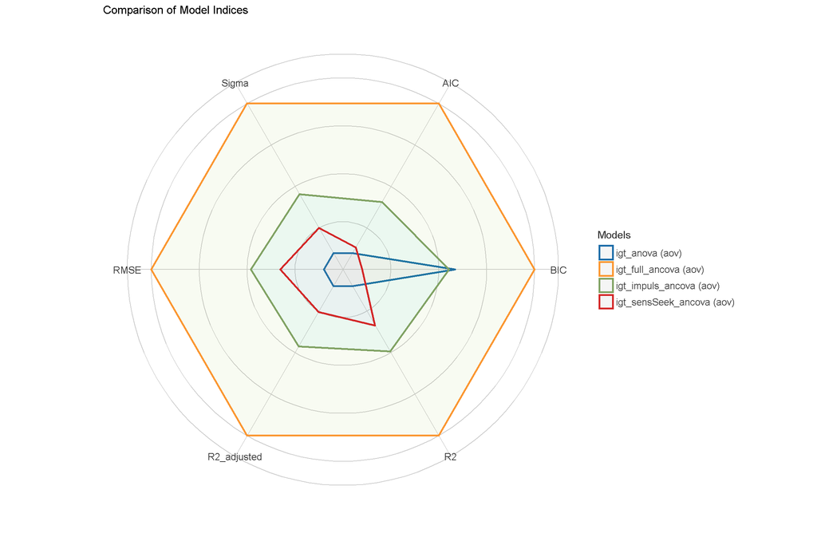

```r
plot(compare_performance(igt_anova, igt_impuls_ancova, igt_sensSeek_ancova, igt_full_ancova))
```

### BART Model

$~$

```r
bart_anova <- aov(BART ~ group, data = tez)

summary.lm(bart_anova)
```

```
Call:
aov(formula = BART ~ group, data = tez)

Residuals:
    Min      1Q  Median      3Q     Max
-22.881  -6.571   0.447   2.776  32.347

Coefficients:
                    Estimate Std. Error t value Pr(>|t|)
(Intercept)          23.1813     1.7085  13.568   <2e-16 ***
groupcontrol_vs_exp   0.8326     1.2081   0.689    0.495
groupbetween_exp      2.0396     2.0924   0.975    0.335
---
Signif. codes:  0 '***' 0.001 '**' 0.01 '*' 0.05 '.' 0.1 ' ' 1

Residual standard error: 11.46 on 42 degrees of freedom
Multiple R-squared:  0.03282,   Adjusted R-squared:  -0.01324
F-statistic: 0.7125 on 2 and 42 DF,  p-value: 0.4962
```

```r
report(bart_anova)
```

```
The ANOVA (formula: BART ~ group) suggests that:

  - The main effect of group is statistically not significant and small (F(2, 42) = 0.71, p = 0.496; Eta2 = 0.03, 90% CI [0.00, 0.13])

Effect sizes were labelled following Field's (2013) recommendations.
```

$~$

#### Step-by-step

We will build up to our full ANCOVA model, meaning we’ll create 3 more models:

1. Controlling for impulsivity
2. Controlling for sensation-seeking
3. Controlling for impulsivity + sensation-seeking

$~$

##### 1. Controlling for Impulsivity

```r
bart_impuls_ancova <- aov(BART ~ barratt_total + group, data = tez)

summary.lm(bart_impuls_ancova)
```

```
Call:
aov(formula = BART ~ barratt_total + group, data = tez)

Residuals:
     Min       1Q   Median       3Q      Max
-23.5361  -6.2431   0.2949   3.0551  31.3639

Coefficients:
                    Estimate Std. Error t value Pr(>|t|)
(Intercept)         25.79254    9.64172   2.675   0.0107 *
barratt_total       -0.08189    0.29746  -0.275   0.7845
groupcontrol_vs_exp  0.83074    1.22161   0.680   0.5003
groupbetween_exp     2.13237    2.14254   0.995   0.3255
---
Signif. codes:  0 '***' 0.001 '**' 0.01 '*' 0.05 '.' 0.1 ' ' 1

Residual standard error: 11.59 on 41 degrees of freedom
Multiple R-squared:  0.0346,    Adjusted R-squared:  -0.03604
F-statistic: 0.4898 on 3 and 41 DF,  p-value: 0.6913
```

$~$

##### 2. Controlling for Sensation-seeking

```r
bart_sensSeek_ancova <- aov(BART ~ sss_total + group, data = tez)

summary.lm(bart_sensSeek_ancova)
```

```
Call:
aov(formula = BART ~ sss_total + group, data = tez)

Residuals:
     Min       1Q   Median       3Q      Max
-22.8418  -7.4737   0.0438   2.6976  31.5613

Coefficients:
                    Estimate Std. Error t value Pr(>|t|)
(Intercept)          25.9768     7.0467   3.686  0.00066 ***
sss_total            -0.1178     0.2879  -0.409  0.68455
groupcontrol_vs_exp   0.7580     1.2338   0.614  0.54238
groupbetween_exp      2.2241     2.1611   1.029  0.30944
---
Signif. codes:  0 '***' 0.001 '**' 0.01 '*' 0.05 '.' 0.1 ' ' 1

Residual standard error: 11.58 on 41 degrees of freedom
Multiple R-squared:  0.03675,   Adjusted R-squared:  -0.03373
F-statistic: 0.5214 on 3 and 41 DF,  p-value: 0.67
```

##### 3. Controlling for Impulsivity + Sensation-seeking

```r
bart_full_ancova <- aov(BART ~ barratt_total + sss_total + group, data = tez)

summary.lm(bart_full_ancova)
```

```
Call:
aov(formula = BART ~ barratt_total + sss_total + group, data = tez)

Residuals:
     Min       1Q   Median       3Q      Max
-23.2402  -7.1647   0.3157   2.7901  31.0686

Coefficients:
                    Estimate Std. Error t value Pr(>|t|)
(Intercept)         27.19799   10.60272   2.565   0.0142 *
barratt_total       -0.04919    0.31600  -0.156   0.8771
sss_total           -0.10315    0.30615  -0.337   0.7379
groupcontrol_vs_exp  0.76614    1.24983   0.613   0.5433
groupbetween_exp     2.25692    2.19740   1.027   0.3106
---
Signif. codes:  0 '***' 0.001 '**' 0.01 '*' 0.05 '.' 0.1 ' ' 1

Residual standard error: 11.72 on 40 degrees of freedom
Multiple R-squared:  0.03733,   Adjusted R-squared:  -0.05893
F-statistic: 0.3878 on 4 and 40 DF,  p-value: 0.8161
```

It seems none of our models are statistically significant.

$~$

##### Comparing Models

```r
compare_performance(bart_anova, bart_impuls_ancova, bart_sensSeek_ancova, bart_full_ancova) %>% flextable() %>% colformat_double(digits = 2)
```

| Name | Model | AIC | BIC | R2 | R2_adjusted | RMSE | Sigma |
| --- | --- | --- | --- | --- | --- | --- | --- |
| bart_anova | aov | 352.10 | 359.33 | 0.03 | -0.01 | 11.07 | 11.46 |
| bart_impuls_ancova | aov | 354.02 | 363.05 | 0.03 | -0.04 | 11.06 | 11.59 |
| bart_sensSeek_ancova | aov | 353.92 | 362.95 | 0.04 | -0.03 | 11.05 | 11.58 |
| bart_full_ancova | aov | 355.89 | 366.73 | 0.04 | -0.06 | 11.05 | 11.72 |

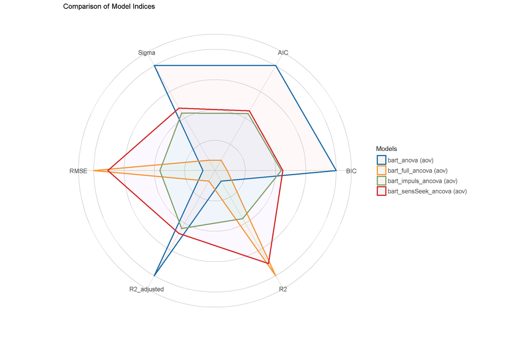

```r
plot(compare_performance(bart_anova, bart_impuls_ancova, bart_sensSeek_ancova, bart_full_ancova))
```